# Bayesian GAM Part3

- lower_distance: smallest plausible distance at which correlation becomes weak, expressed as a proportion of the observed predictor range.
- upper_distance: largest plausible distance at which correlation becomes weak. weak_correlation: the correlation considered ecologically negligible, commonly 0.1.
- probability: the prior probability assigned between the lower and upper distances, commonly 0.90.

As a general guide:

- smaller distances favour rapidly changing, local responses
- larger distances favour broad, smooth responses
- wider intervals represent greater prior uncertainty

```r
prior_info <- invgamma_from_weak_distance(
  lower_distance = 0.10,
  upper_distance = 0.5,
  weak_correlation = 0.10,
  probability = 0.90
)

prior_info
```

```
$shape
[1] 4.589686

$scale
[1] 0.4000431

$weak_correlation
[1] 0.1

$probability
[1] 0.9

$lscale_quantiles
     lower     median      upper
0.04659906 0.09388471 0.23299640

$weak_distance_quantiles
    lower    median     upper
0.1000000 0.2014734 0.5000024

$prior
[1] "inv_gamma(4.589686, 0.400043)"
```

**Default brms priors**

```r
x <- wq_sub$dt_num
# Pairwise Euclidean distances
dx <- as.numeric(dist(x))
# gp(..., scale = TRUE) rescales distances so that
# the maximum distance is one
dx_scaled <- dx / max(dx)
dmin <- min(dx_scaled[dx_scaled > 0])
dmax <- max(dx_scaled)
# Ratio that the inverse-gamma quantiles must satisfy
target_ratio <- dmax / dmin
shape_equation <- function(shape) {
  qgamma(0.99, shape = shape, rate = 1) /
    qgamma(0.01, shape = shape, rate = 1) -
    target_ratio
}
alpha <- uniroot(
  shape_equation,
  interval = c(0.01, 1000)
)$root
alpha
```

```
[1] 1.523336
```

```r
beta <- dmin * qgamma(
  0.99,
  shape = alpha,
  rate = 1
)
beta
```

```
[1] 0.06072729
```

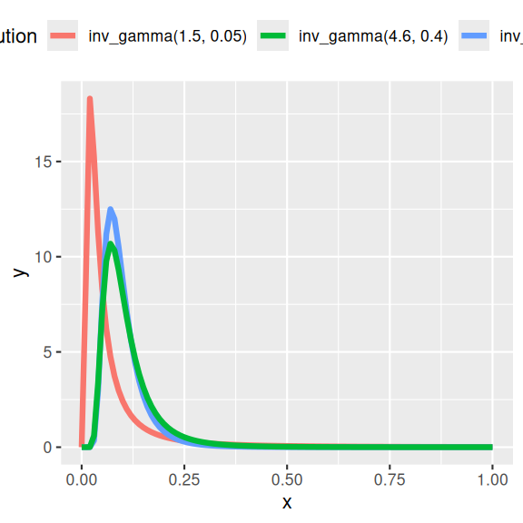

```r
standist::visualize(
  "inv_gamma(1.5, 0.05)",
  "inv_gamma(6, 0.5)",
  "inv_gamma(4.6, 0.4)",
    xlim = c(0, 1)
)
```

**Fit model**

```r
wq_form <- bf(NOx | cens(NOx_flag) ~ gp(dt_num), family = Gamma(link = "log"))
wq_sub |> summarise(
    median(log(NOx)), mad(log(NOx)),
    mad(log(NOx)) / mad(scale(dt_num))
)
```

```
# A tibble: 1 × 3
  `median(log(NOx))` `mad(log(NOx))` `mad(log(NOx))/mad(scale(dt_num))`
               <dbl>           <dbl>                              <dbl>
1              -3.10           0.925                              0.747
```

```r
get_prior(wq_form, data = wq_sub)
```

```
                         prior     class     coef group resp dpar nlpar lb ub
       student_t(3, -3.1, 2.5) Intercept
                        (flat)    lscale                                 0
 inv_gamma(1.523334, 0.060727)    lscale gpdt_num                        0
          student_t(3, 0, 2.5)      sdgp                                 0
          student_t(3, 0, 2.5)      sdgp gpdt_num                        0
             gamma(0.01, 0.01)     shape                                 0
 tag       source
          default
          default
          default
          default
     (vectorized)
          default
```

```r
priors <- prior(normal(-3.1, 1), class = "Intercept") +
  prior(gamma(0.01, 0.01), class = "shape") +
  prior(inv_gamma(4.6, 0.4), class = "lscale", coef = "gpdt_num") +
  prior(student_t(3, 0, 1), class =  "sdgp")

wq_brm2b <- brm(wq_form,
                 data = wq_sub,
                 prior = priors,
                 sample_prior = 'only',
                 iter = 5000,
                 warmup = 1000,
                 thin = 5,
                 chains = 3, cores =  3,
                 backend = "rstan",
                 seed =  123,
                 control =  list(adapt_delta = 0.99, max_treedepth = 20),
                 refresh = 0)
```

```r
wq_brm2b |> conditional_effects() |>  plot(points=TRUE)
wq_brm2b |> conditional_effects() |>  plot(points=TRUE) |>
  _[[1]] +
  scale_y_log10()
```

[output not shown]

**Sample prior and posterior**

```r
wq_brm3b <- update(wq_brm2b, sample_prior = "yes", cores =  3, refresh =  0)
```

```
The desired updates require recompiling the model
```

**Plotting prior and posterior**

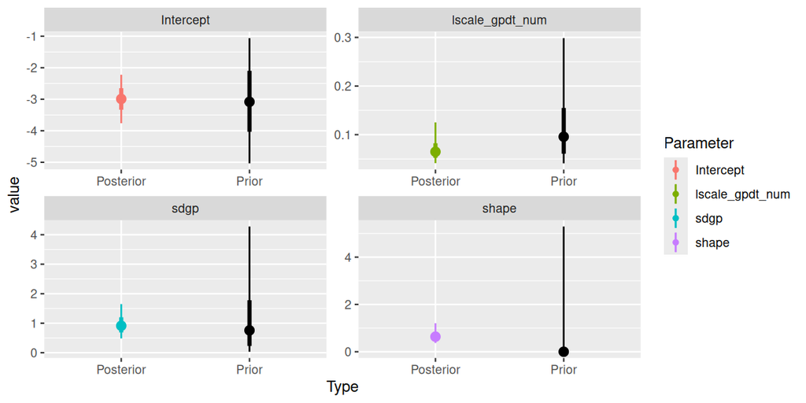

```r
wq_brm3b |> SUYR_prior_and_posterior()
```

```r
wq_brm3b |> get_variables()
```

```
 [1] "b_Intercept"              "sdgp_gpdt_num"
 [3] "lscale_gpdt_num"          "shape"
 [5] "Intercept"                "zgp_gpdt_num[1]"
 [7] "zgp_gpdt_num[2]"          "zgp_gpdt_num[3]"
 [9] "zgp_gpdt_num[4]"          "zgp_gpdt_num[5]"
[11] "zgp_gpdt_num[6]"          "zgp_gpdt_num[7]"
[13] "zgp_gpdt_num[8]"          "zgp_gpdt_num[9]"
[15] "zgp_gpdt_num[10]"         "zgp_gpdt_num[11]"
[17] "zgp_gpdt_num[12]"         "zgp_gpdt_num[13]"
[19] "zgp_gpdt_num[14]"         "zgp_gpdt_num[15]"
[21] "zgp_gpdt_num[16]"         "zgp_gpdt_num[17]"
[23] "zgp_gpdt_num[18]"         "zgp_gpdt_num[19]"
[25] "zgp_gpdt_num[20]"         "zgp_gpdt_num[21]"
[27] "zgp_gpdt_num[22]"         "zgp_gpdt_num[23]"
[29] "zgp_gpdt_num[24]"         "zgp_gpdt_num[25]"
```

[output cut: 18 more lines]

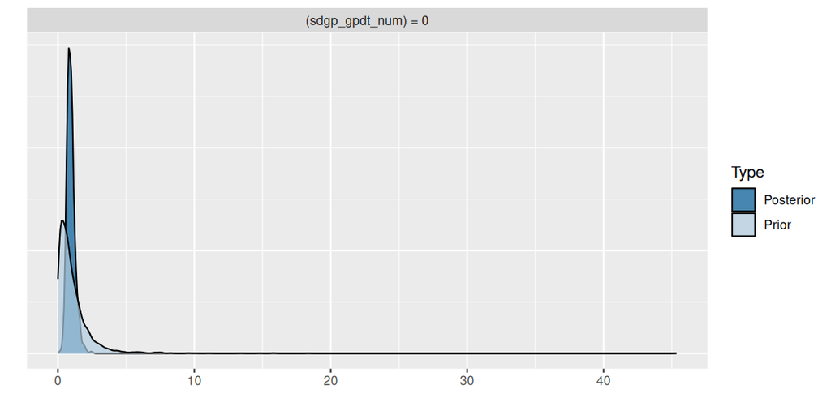

```r
wq_brm3b |> hypothesis('sdgp_gpdt_num = 0', class = '') |> plot()
```

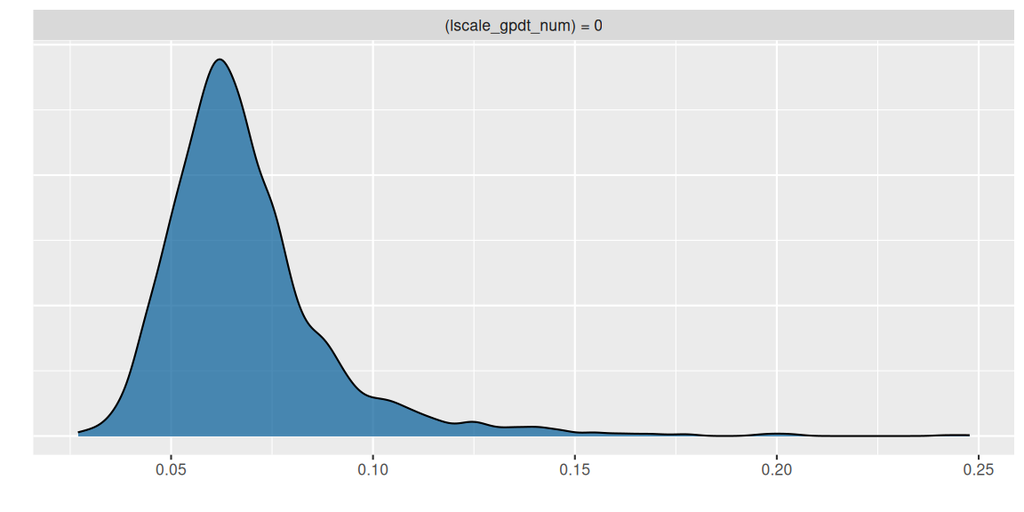

```r
wq_brm3b |> hypothesis('lscale_gpdt_num = 0', class = '') |> plot()
```

**Conditional effects**

```
Ignoring unknown labels:
• fill : "NA"
• colour : "NA"
Ignoring unknown labels:
• fill : "NA"
• colour : "NA"
```

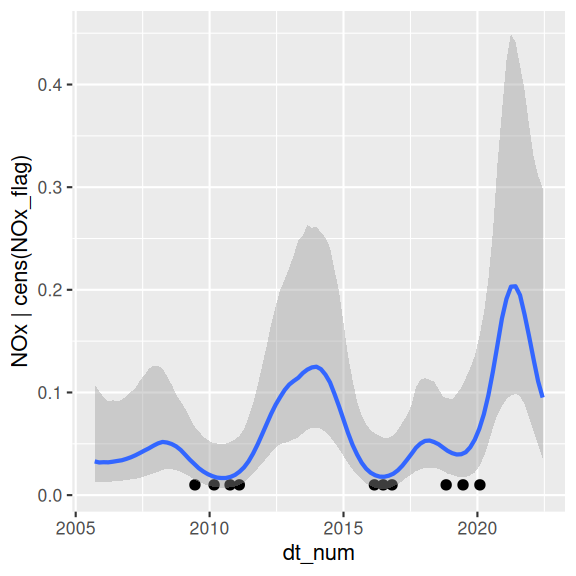

```
Ignoring unknown labels:
• fill : "NA"
• colour : "NA"
```

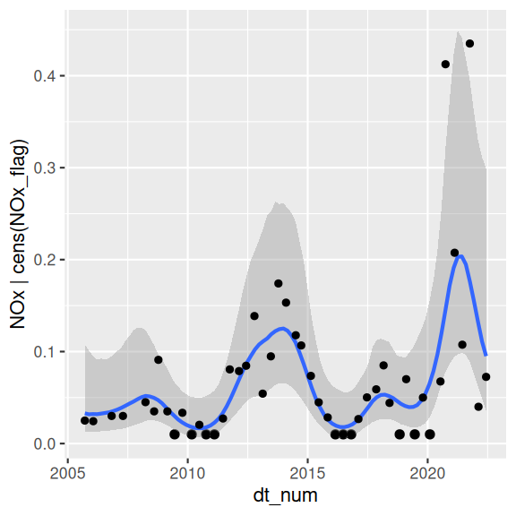

```r
wq_brm3b |> conditional_effects() |>  plot(points=TRUE) |>
  _[[1]] +
  geom_point(data = wq_sub, inherit.aes = FALSE,
             aes(y = NOx, x = dt_num))
```

```
Ignoring unknown labels:
• fill : "NA"
• colour : "NA"
Ignoring unknown labels:
• fill : "NA"
• colour : "NA"
```

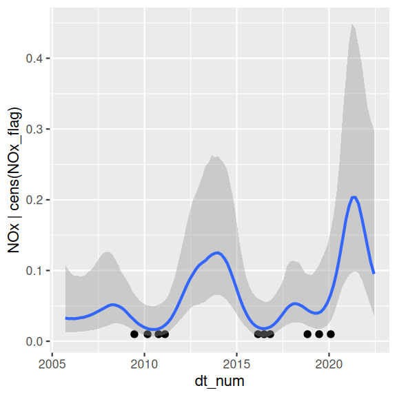

```
Ignoring unknown labels:
• colour : "NA"
Ignoring unknown labels:
• colour : "NA"
```

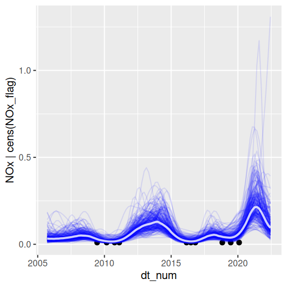

```
Ignoring unknown labels:
• fill : "NA"
• colour : "NA"
Ignoring unknown labels:
• colour : "NA"
```

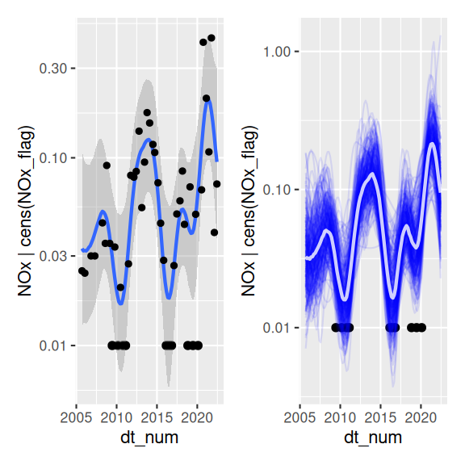

```r
wq_brm3b |> conditional_effects() |>  plot(points=TRUE) |>
  _[[1]] +
  geom_point(data = wq_sub, inherit.aes = FALSE,
             aes(y = NOx, x = dt_num)) +
  scale_y_log10() +
wq_brm3b |> conditional_effects(spaghetti = TRUE, ndraws =  250) |>  plot(points=TRUE) |>
  _[[1]] +
  scale_y_log10()
```

**MCMC sampling diagnostics**

**stan plots**

```
'pars' not specified. Showing first 10 parameters by default.
```

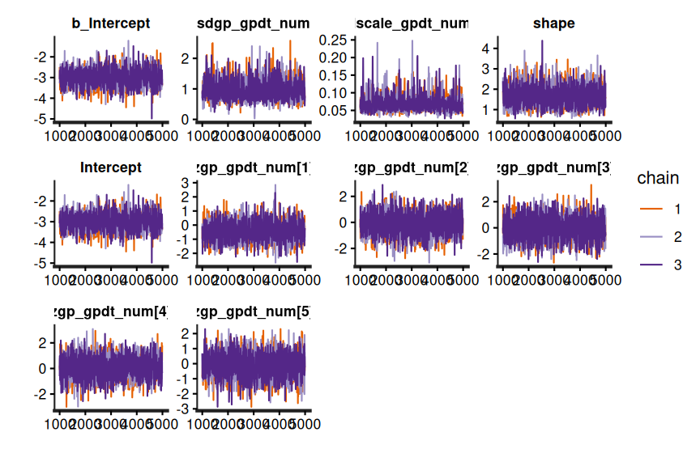

```r
wq_brm3b$fit |> stan_trace()
```

```
'pars' not specified. Showing first 10 parameters by default.
```

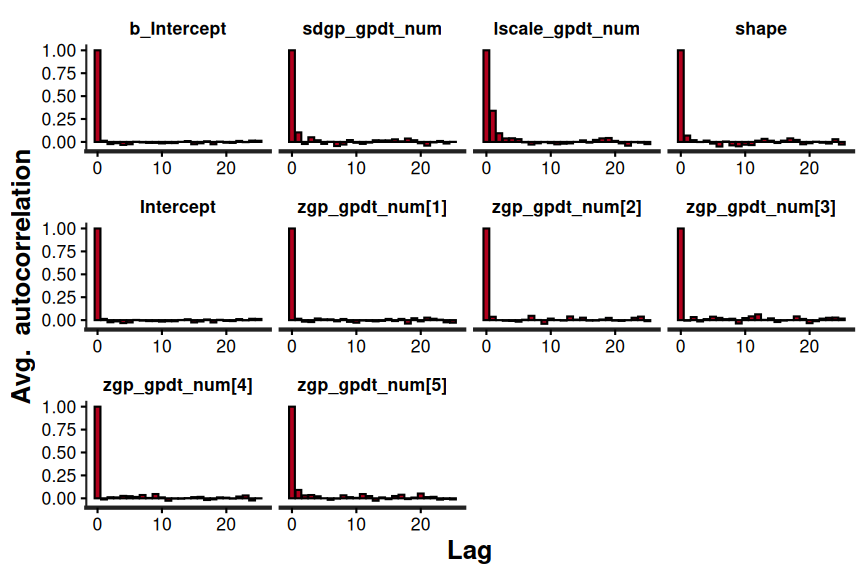

```r
wq_brm3b$fit |> stan_ac()
```

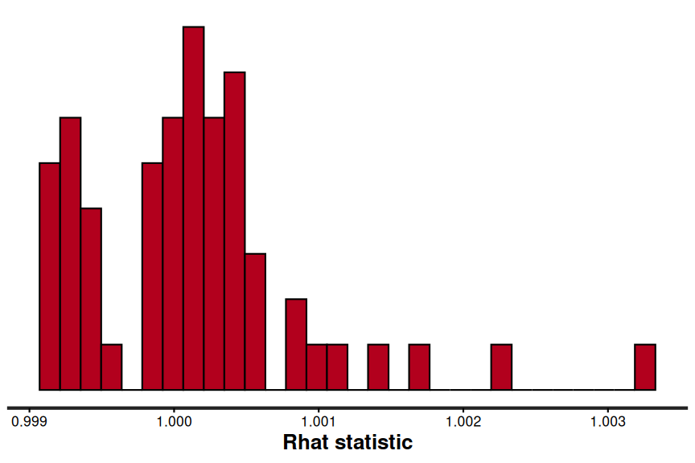

```r
wq_brm3b$fit |> stan_rhat()
```

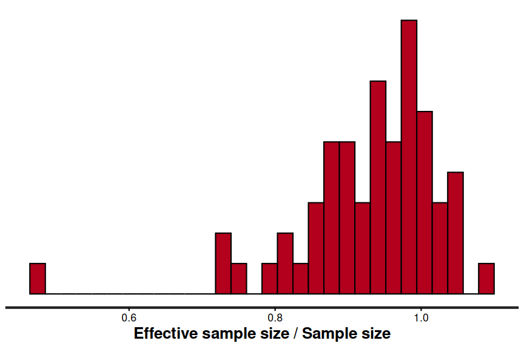

```r
wq_brm3b$fit |> stan_ess()
```

**Model validation**

**pp check**

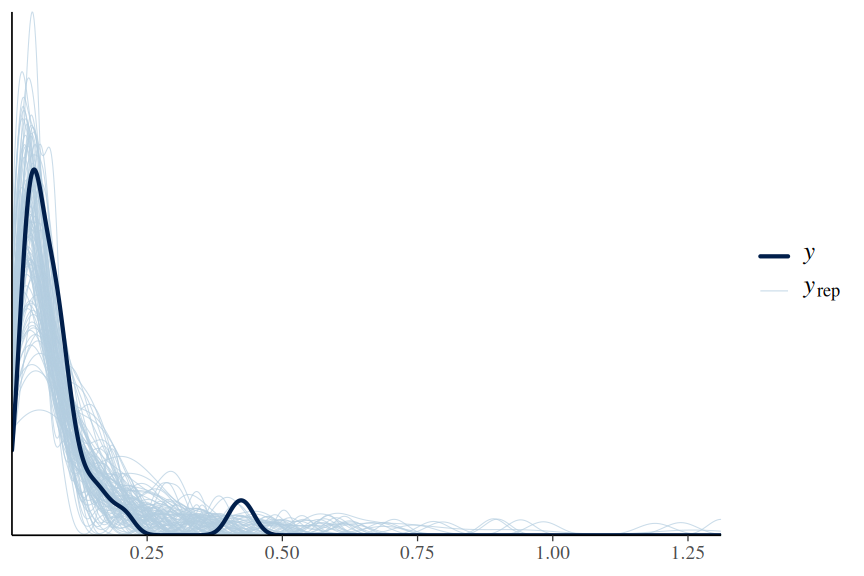

```r
wq_brm3b |> pp_check( type='dens_overlay', ndraws=100)
```

**DHARMa residuals**

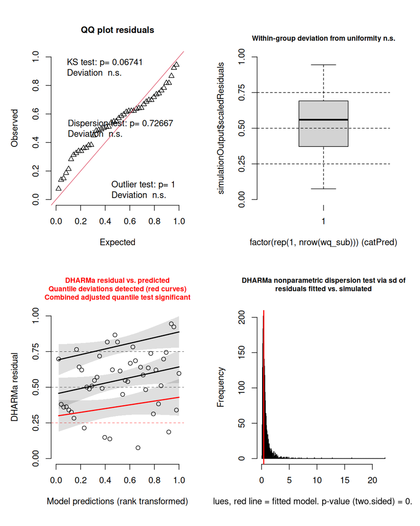

```r
wq_resids <- make_brms_dharma_res(wq_brm3b, integerResponse = FALSE)
wrap_elements(~testUniformity(wq_resids)) +
  wrap_elements(~plotResiduals(wq_resids, form = factor(rep(1, nrow(wq_sub))))) +
  wrap_elements(~plotResiduals(wq_resids, quantreg = TRUE)) +
  wrap_elements(~testDispersion(wq_resids))
```

**Find the peak**

```r
newdata <- with(wq_sub, data.frame(
  dt_num = seq(min(2010), max(2017), length = 1000)
))
wq_peak <-
    add_epred_draws(
        object = wq_brm3b, newdata = newdata,
        re_formula = NA,
        ndraws = 1000
    ) |>
    ungroup() |>
    group_by(.draw) |>
  summarise(x = dt_num[which.max(.epred)],
    Nox = .epred[which.max(.epred)],
    .groups = "keep") |>
    ungroup() |>
  median_hdci(.width = 0.95) |>
  mutate(across(matches("^x"), lubridate::date_decimal)) |>
  mutate(across(matches("^x"), as.Date)) |>
  as.data.frame()
wq_peak
```

```
           x    x.lower    x.upper     Nox  Nox.lower Nox.upper .width .point
1 2013-10-17 2012-04-01 2014-09-19 0.15026 0.07059054 0.2843165   0.95 median
  .interval
1      hdci
```

## 6.2 Date conditional on season

**GAM**

**Fit model**

```r
wq_form <- bf(NOx | cens(NOx_flag) ~ s(scale(dt_num), by = Season),
  family = Gamma(link = "log"))
get_prior(wq_form, data = wq_sub)
```

```
                   prior     class                          coef group resp
                  (flat)         b
                  (flat)         b      sscaledt_num:SeasonDry_1
                  (flat)         b      sscaledt_num:SeasonWet_1
 student_t(3, -3.1, 2.5) Intercept
    student_t(3, 0, 2.5)       sds
    student_t(3, 0, 2.5)       sds s(scale(dt_num), by = Season)
       gamma(0.01, 0.01)     shape
 dpar nlpar lb ub tag       source
                           default
                      (vectorized)
                      (vectorized)
                           default
             0             default
             0        (vectorized)
             0             default
```

```r
priors <- prior(normal(-3.1, 1),  class='Intercept') +
  prior(normal(0, 10), class='b') +
  prior(gamma(0.01, 0.01),  class='shape') +
  prior(student_t(3, 0, 10), class =  "sds")

wq_brm4 <- brm(wq_form,
  data = wq_sub,
  prior = priors,
  sample_prior = 'yes',
  iter = 3000,
  warmup = 1000,
  chains = 3, cores =  3,
  thin = 5,
  backend = "rstan",
  seed =  123,
  control =  list(adapt_delta =  0.99, max_treedepth = 20),
  refresh = 0)
```

**Partial effects plots**

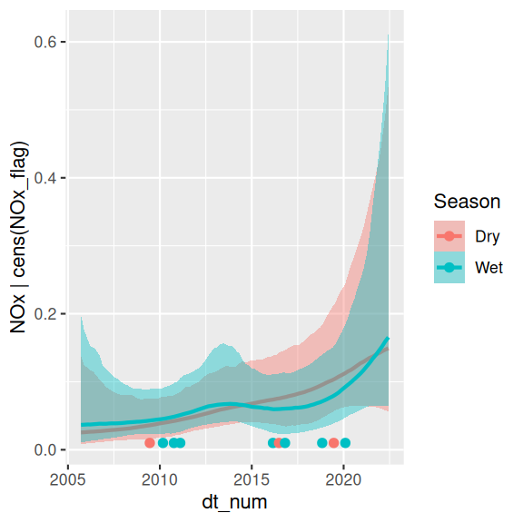

```r
wq_brm4 |> conditional_effects(effects = "dt_num:Season") |>  plot(points=TRUE)
```

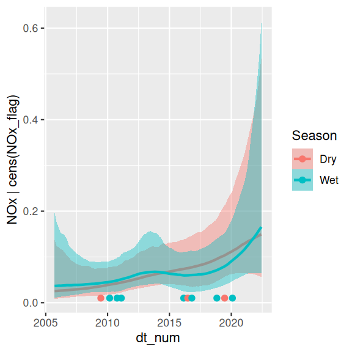

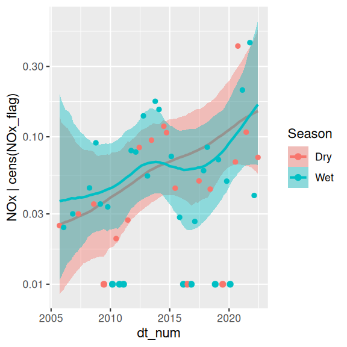

```r
wq_brm4 |> conditional_effects(effects = "dt_num:Season") |>  plot(points=TRUE) |>
  _[[1]] +
  scale_y_log10() +
  geom_point(data = wq_sub, inherit.aes = FALSE,
             aes(y = NOx, x = dt_num, colour = Season))
```

**Plot prior vs posterior**

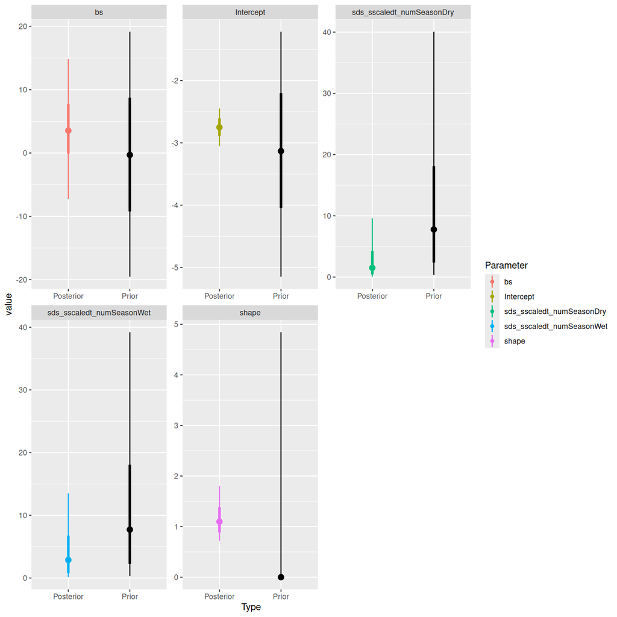

```r
wq_brm4 |> SUYR_prior_and_posterior()
```

**DHARMa residuals**

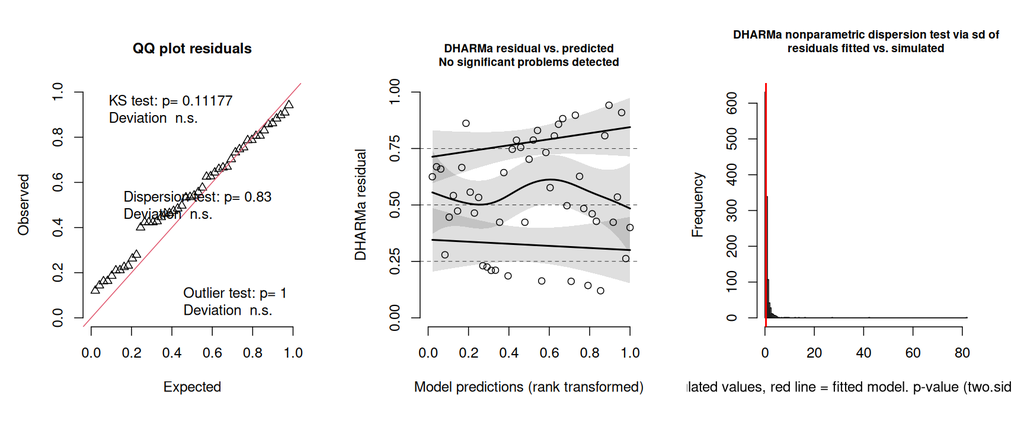

```r
wq.resids <- make_brms_dharma_res(wq_brm4, integerResponse = FALSE)
wrap_elements(~testUniformity(wq.resids)) +
  ## wrap_elements(~plotResiduals(wq.resids, form = factor(rep(1, nrow(wq_sub))))) +
  wrap_elements(~plotResiduals(wq.resids, quantreg = TRUE)) +
  wrap_elements(~testDispersion(wq.resids))
```

```r
## testTemporalAutocorrelation(wq.resids, time =  wq_sub$dt_num)
## resids1 <- recalculateResiduals(wq.resids, group =  wq_sub$dt_num, aggregateBy =  mean)
## testTemporalAutocorrelation(resids1, time =  wq_sub$dt_num)
```

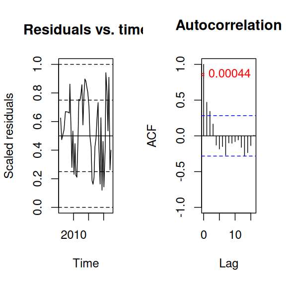

```
    Durbin-Watson test

data:  simulationOutput$scaledResiduals ~ 1
DW = 1.0524, p-value = 0.0004405
alternative hypothesis: true autocorrelation is not 0
```

```r
dt_num <- wq_brm4$data$dt_num
## testTemporalAutocorrelation(wq.resids, time =  dt_num)
resids1 <- recalculateResiduals(wq.resids, group =  dt_num, aggregateBy =  mean)
testTemporalAutocorrelation(resids1, time =  dt_num)
```

**Find the peak**

```r
newdata <- with(wq_sub, data.frame(
    dt_num = seq(min(2010), max(2017), length = 1000)
)) |>
  crossing(Season = unique(wq_sub$Season))
wq_peak <-
  add_epred_draws(
    object = wq_brm4, newdata = newdata,
    re_formula = NA,
    ndraws = 1000
  ) |>
  ungroup() |>
  group_by(Season, .draw) |>
  summarise(x = dt_num[which.max(.epred)],
    Nox = .epred[which.max(.epred)],
    .groups = "keep") |>
  ungroup() |>
  group_by(Season) |>
  median_hdci(.width = 0.95) |>
  mutate(across(matches("^x"), lubridate::date_decimal)) |>
  mutate(across(matches("^x"), as.Date)) |>
  as.data.frame()
wq_peak
```

```
  Season          x    x.lower    x.upper        Nox  Nox.lower Nox.upper
1    Dry 2017-01-01 2012-07-30 2017-01-01 0.08393114 0.04964602 0.1517812
2    Wet 2014-01-14 2010-01-01 2017-01-01 0.08185745 0.04736936 0.1592001
  .width .point .interval
1   0.95 median      hdci
2   0.95 median      hdci
```

**Gaussian Process**

**Fit model**

```r
wq_form <- bf(NOx | cens(NOx_flag) ~ gp(dt_num, by = Season), family = Gamma(link = "log"))
wq_sub |> summarise(
    median(log(NOx)), mad(log(NOx)),
    mad(log(NOx)) / mad(scale(dt_num))
)
```

```
# A tibble: 1 × 3
  `median(log(NOx))` `mad(log(NOx))` `mad(log(NOx))/mad(scale(dt_num))`
               <dbl>           <dbl>                              <dbl>
1              -3.10           0.925                              0.747
```

```r
get_prior(wq_form, data = wq_sub)
```

```
                         prior     class              coef group resp dpar
       student_t(3, -3.1, 2.5) Intercept
                        (flat)    lscale
 inv_gamma(1.611781, 0.074151)    lscale gpdt_numSeasonDry
 inv_gamma(1.791004, 0.105463)    lscale gpdt_numSeasonWet
          student_t(3, 0, 2.5)      sdgp
          student_t(3, 0, 2.5)      sdgp gpdt_numSeasonDry
          student_t(3, 0, 2.5)      sdgp gpdt_numSeasonWet
             gamma(0.01, 0.01)     shape
 nlpar lb ub tag       source
                      default
        0             default
        0             default
        0             default
        0             default
        0        (vectorized)
        0        (vectorized)
        0             default
```

```r
priors <- prior(normal(-3.1, 1), class = "Intercept") +
  prior(gamma(0.01, 0.01), class = "shape") +
  prior(inv_gamma(4.6, 0.4), class = "lscale", coef = "gpdt_numSeasonDry") +
  prior(inv_gamma(4.6, 0.4), class = "lscale", coef = "gpdt_numSeasonWet") +
  prior(student_t(3, 0, 1), class =  "sdgp")

wq_brm5a <- brm(wq_form,
                 data = wq_sub,
                 prior = priors,
                 sample_prior = 'only',
                 iter = 5000,
                 warmup = 1000,
                 thin = 5,
                 chains = 3, cores =  3,
                 backend = "rstan",
                 seed =  123,
                 control =  list(adapt_delta = 0.99, max_treedepth = 20),
                 refresh = 0)
```

```r
wq_brm5a |> get_variables()
```

```
 [1] "b_Intercept"               "sdgp_gpdt_numSeasonDry"
 [3] "sdgp_gpdt_numSeasonWet"    "lscale_gpdt_numSeasonDry"
 [5] "lscale_gpdt_numSeasonWet"  "shape"
 [7] "Intercept"                 "zgp_gpdt_numSeasonDry[1]"
 [9] "zgp_gpdt_numSeasonDry[2]"  "zgp_gpdt_numSeasonDry[3]"
[11] "zgp_gpdt_numSeasonDry[4]"  "zgp_gpdt_numSeasonDry[5]"
[13] "zgp_gpdt_numSeasonDry[6]"  "zgp_gpdt_numSeasonDry[7]"
[15] "zgp_gpdt_numSeasonDry[8]"  "zgp_gpdt_numSeasonDry[9]"
[17] "zgp_gpdt_numSeasonDry[10]" "zgp_gpdt_numSeasonDry[11]"
[19] "zgp_gpdt_numSeasonDry[12]" "zgp_gpdt_numSeasonDry[13]"
[21] "zgp_gpdt_numSeasonDry[14]" "zgp_gpdt_numSeasonDry[15]"
[23] "zgp_gpdt_numSeasonDry[16]" "zgp_gpdt_numSeasonDry[17]"
[25] "zgp_gpdt_numSeasonDry[18]" "zgp_gpdt_numSeasonDry[19]"
[27] "zgp_gpdt_numSeasonWet[1]"  "zgp_gpdt_numSeasonWet[2]"
[29] "zgp_gpdt_numSeasonWet[3]"  "zgp_gpdt_numSeasonWet[4]"
```

[output cut: 17 more lines]

```r
wq_brm5a |> conditional_effects(effects = "dt_num:Season") |>  plot(points=TRUE)
```

```
Error:
! error in evaluating the argument 'x' in selecting a method for function 'plot': The Gaussian process covariance matrix is not positive definite.
This occurs for numerical reasons. Setting 'nug' above 1e-08 may help.
```

```r
wq_brm5a |>
    conditional_effects(effects = "dt_num:Season") |>
    plot(points = TRUE) |>
    _[[1]] +
  scale_y_log10() +
  geom_point(
    data = wq_sub, inherit.aes = FALSE,
    aes(y = NOx, x = dt_num, colour = Season)
  )
```

```
Error:
! error in evaluating the argument 'x' in selecting a method for function 'plot': The Gaussian process covariance matrix is not positive definite.
This occurs for numerical reasons. Setting 'nug' above 1e-08 may help.
```

**Sample prior and posterior**

```r
wq_brm5b <- update(wq_brm5a, sample_prior = "yes", cores =  3, refresh =  0)
```

```
The desired updates require recompiling the model
```

**Partial effects plot**

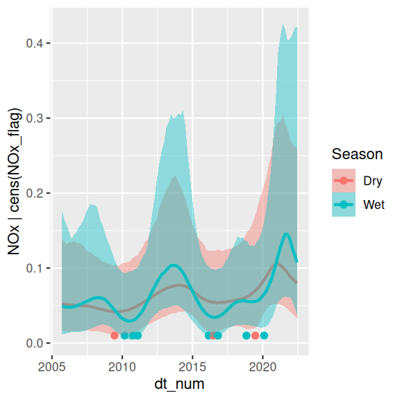

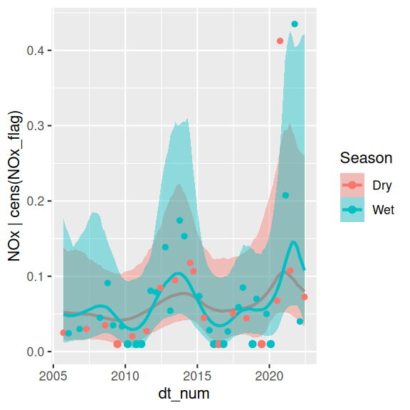

```r
wq_brm5b |> conditional_effects(effects = "dt_num:Season") |>  plot(points=TRUE) |>
  _[[1]] +
  geom_point(data = wq_sub, inherit.aes = FALSE,
             aes(y = NOx, x = dt_num, colour = Season))
```

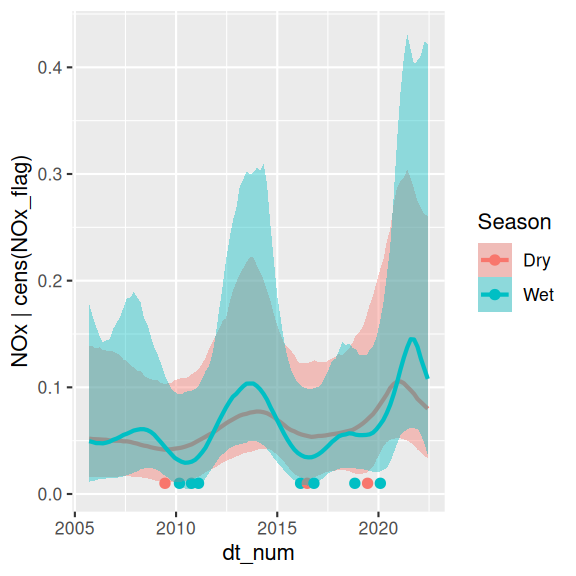

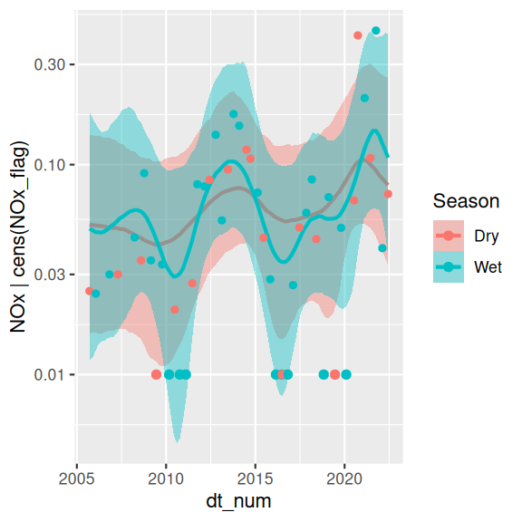

```r
wq_brm5b |> conditional_effects(effects = "dt_num:Season") |>  plot(points=TRUE) |>
  _[[1]] +
  geom_point(data = wq_sub, inherit.aes = FALSE,
             aes(y = NOx, x = dt_num, colour = Season)) +
  scale_y_log10()
```

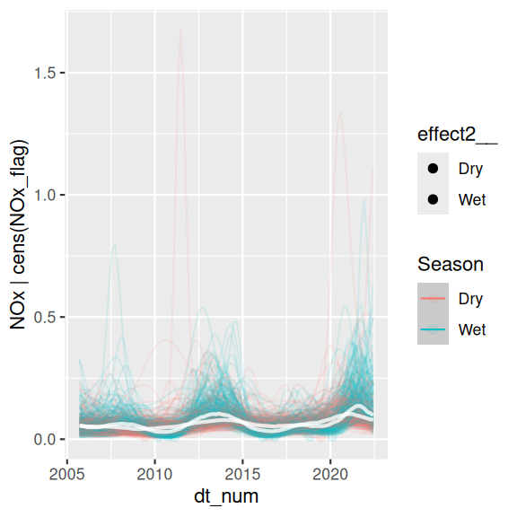

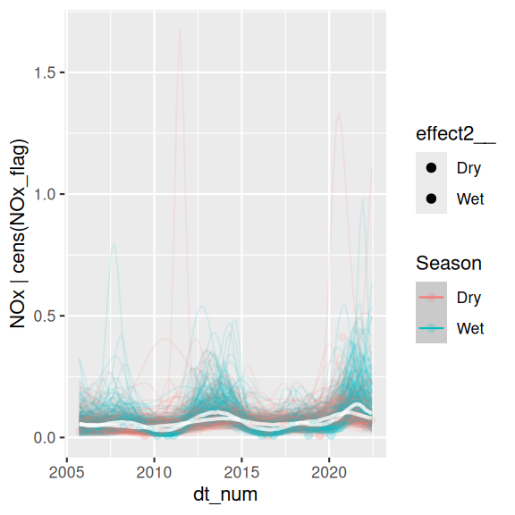

```r
wq_brm5b |>
    conditional_effects(
        effects = "dt_num:Season",
        spaghetti = TRUE, ndraws = 250
    ) |>
    plot(points = TRUE) |>
  _[[1]] +
  geom_point(data = wq_sub, inherit.aes = FALSE,
             aes(y = NOx, x = dt_num, colour = Season))
```

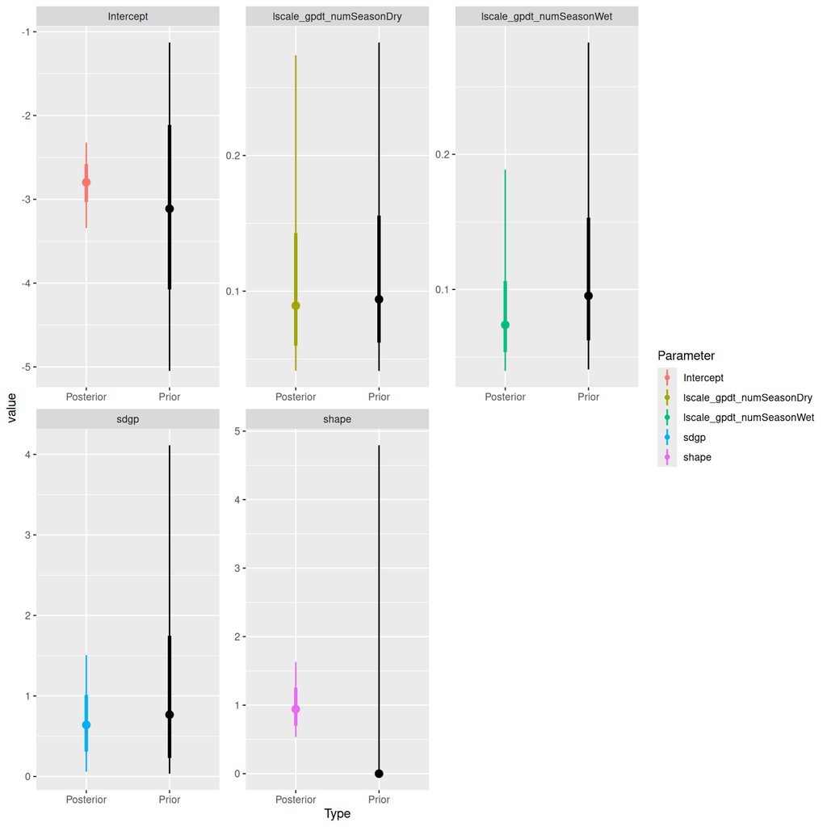

```r
wq_brm5b |> SUYR_prior_and_posterior()
```

Might be worth making the lscale prior wider

**DHARMa residuals**

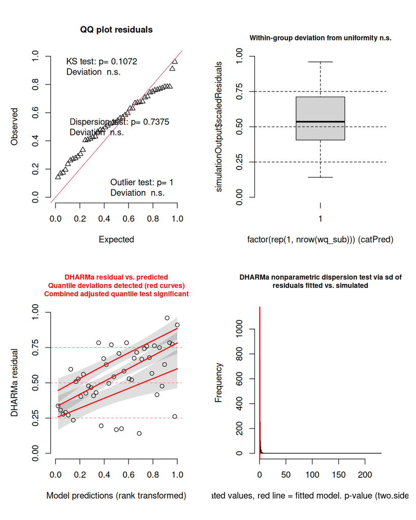

```r
wq_resids <- make_brms_dharma_res(wq_brm5b, integerResponse = FALSE)
wrap_elements(~testUniformity(wq_resids)) +
  wrap_elements(~plotResiduals(wq_resids, form = factor(rep(1, nrow(wq_sub))))) +
  wrap_elements(~plotResiduals(wq_resids, quantreg = TRUE)) +
  wrap_elements(~testDispersion(wq_resids))
```

**Find the peak**

```r
newdata <- with(wq_sub, data.frame(
    dt_num = seq(min(2010), max(2017), length = 1000)
)) |>
  crossing(Season = unique(wq_sub$Season))
wq_peak <-
  add_epred_draws(
    object = wq_brm5b, newdata = newdata,
    re_formula = NA,
    ndraws = 1000
  ) |>
  ungroup() |>
  group_by(Season, .draw) |>
  summarise(x = dt_num[which.max(.epred)],
    Nox = .epred[which.max(.epred)],
    .groups = "keep") |>
  ungroup() |>
  group_by(Season) |>
  median_hdci(.width = 0.95) |>
  mutate(across(matches("^x"), lubridate::date_decimal)) |>
  mutate(across(matches("^x"), as.Date)) |>
  as.data.frame()
wq_peak
```

```
  Season          x    x.lower    x.upper       Nox  Nox.lower Nox.upper .width
1    Dry 2013-11-12 2010-02-08 2017-01-01 0.0970156 0.04341639  0.232447   0.95
2    Wet 2013-08-21 2012-01-06 2017-01-01 0.1325915 0.05379460  0.323730   0.95
  .point .interval
1 median      hdci
2 median      hdci
```

## 6.3 Inter/Intra annual trends

**GAM**

**Fit model**

```r
wq_form <- bf(NOx | cens(NOx_flag) ~ s(scale(dt_num)) +
                s(scale(Mnth), bs = "cc"),
  family = Gamma(link = "log"))
get_prior(wq_form, data = wq_sub)
```

```
                   prior     class                      coef group resp dpar
                  (flat)         b
                  (flat)         b            sscaledt_num_1
 student_t(3, -3.1, 2.5) Intercept
    student_t(3, 0, 2.5)       sds
    student_t(3, 0, 2.5)       sds          s(scale(dt_num))
    student_t(3, 0, 2.5)       sds s(scale(Mnth), bs = "cc")
       gamma(0.01, 0.01)     shape
 nlpar lb ub tag       source
                      default
                 (vectorized)
                      default
        0             default
        0        (vectorized)
        0        (vectorized)
        0             default
```

```r
priors <- prior(normal(-3.1, 1),  class='Intercept') +
  prior(normal(0, 10), class='b') +
  prior(gamma(0.01, 0.01),  class='shape') +
  prior(student_t(3, 0, 10), class =  "sds")

wq_brm6a <- brm(wq_form,
  data = wq_sub,
  prior = priors,
  sample_prior = 'yes',
  iter = 3000,
  warmup = 1000,
  chains = 3, cores =  3,
  thin = 5,
  backend = "rstan",
  seed =  123,
  control =  list(adapt_delta =  0.99, max_treedepth = 20),
  refresh = 0)
```

**Partial effects plot**

[output not shown]

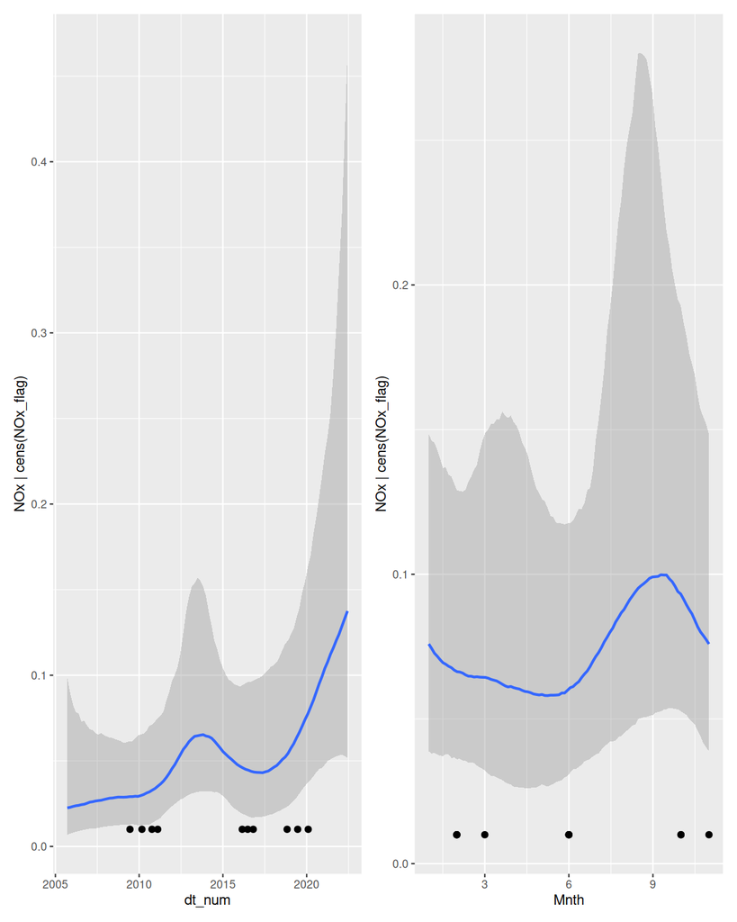

```r
wq_brm6a |>
    conditional_effects() |>
    plot(ask = FALSE, points = TRUE, plot = FALSE) |>
  wrap_plots()
```

```
Ignoring unknown labels:
• fill : "NA"
• colour : "NA"
Ignoring unknown labels:
• fill : "NA"
• colour : "NA"
```

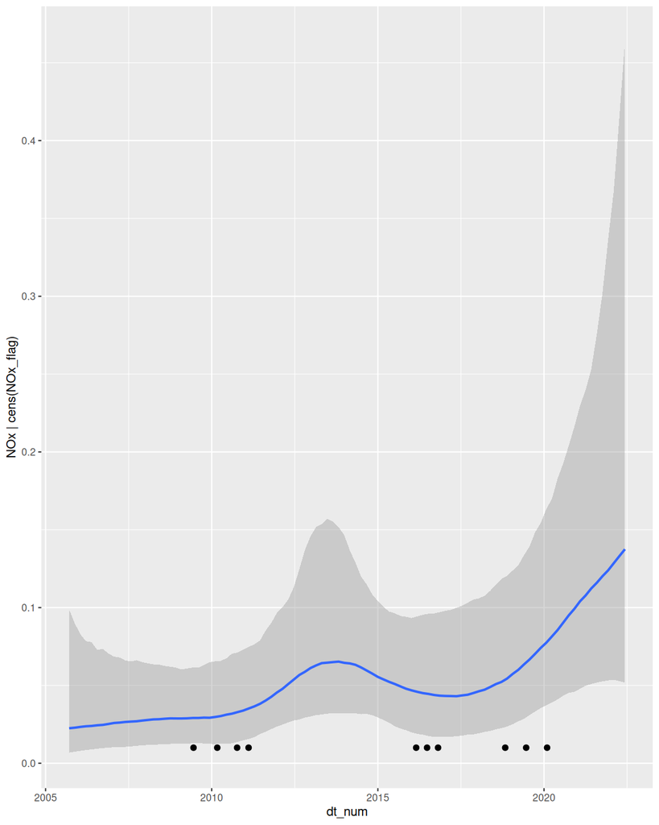

```
Ignoring unknown labels:
• fill : "NA"
```

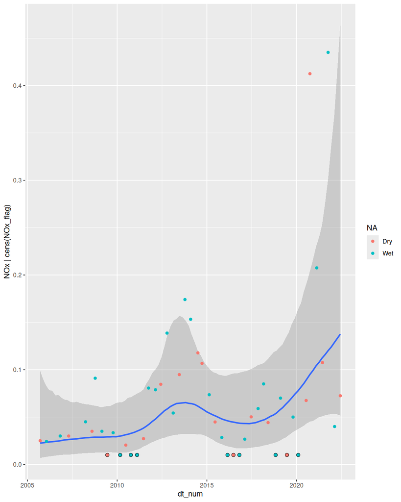

```r
wq_brm6a |> conditional_effects(effects = "dt_num") |>  plot(points=TRUE) |>
  _[[1]] +
  geom_point(data = wq_sub, inherit.aes = FALSE,
             aes(y = NOx, x = dt_num, colour = Season))
```

```
Ignoring unknown labels:
• fill : "NA"
• colour : "NA"
Ignoring unknown labels:
• fill : "NA"
• colour : "NA"
```

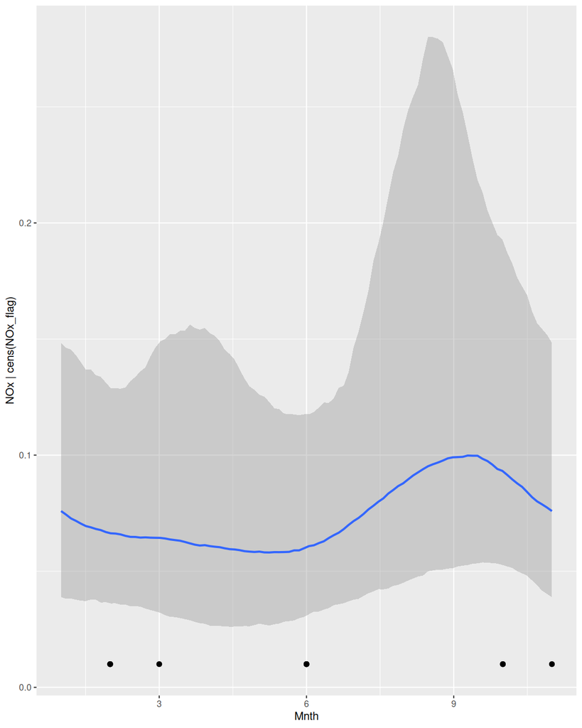

```
Ignoring unknown labels:
• fill : "NA"
• colour : "NA"
```

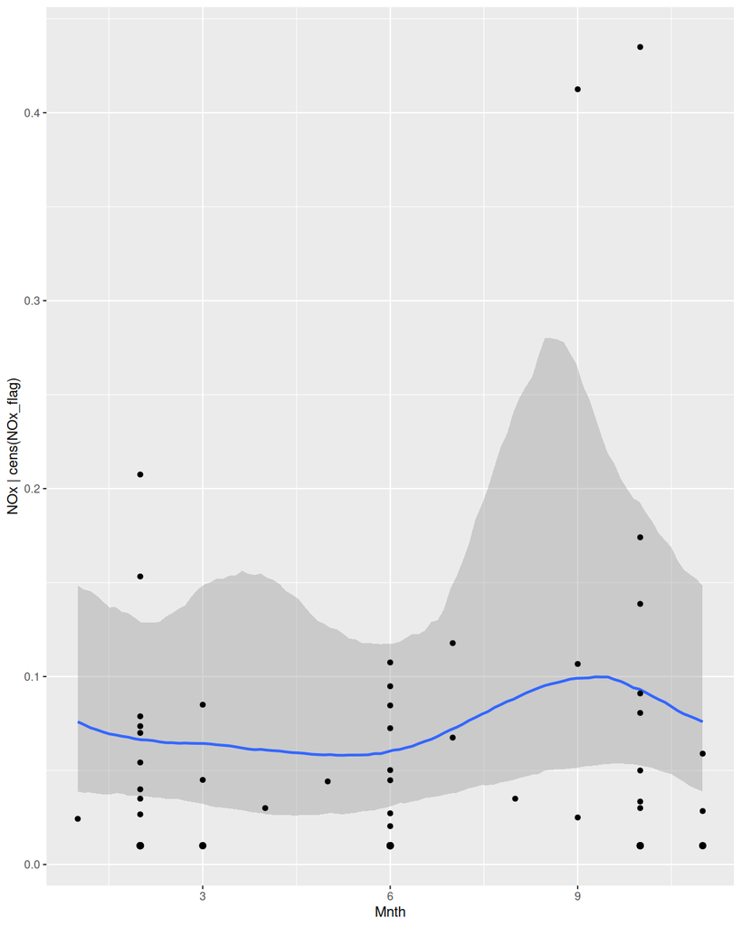

```r
wq_brm6a |> conditional_effects(effects = "Mnth") |>  plot(points=TRUE) |>
  _[[1]] +
  geom_point(data = wq_sub, inherit.aes = FALSE,
             aes(y = NOx, x = Mnth))
```

**Prior vs Posterior**

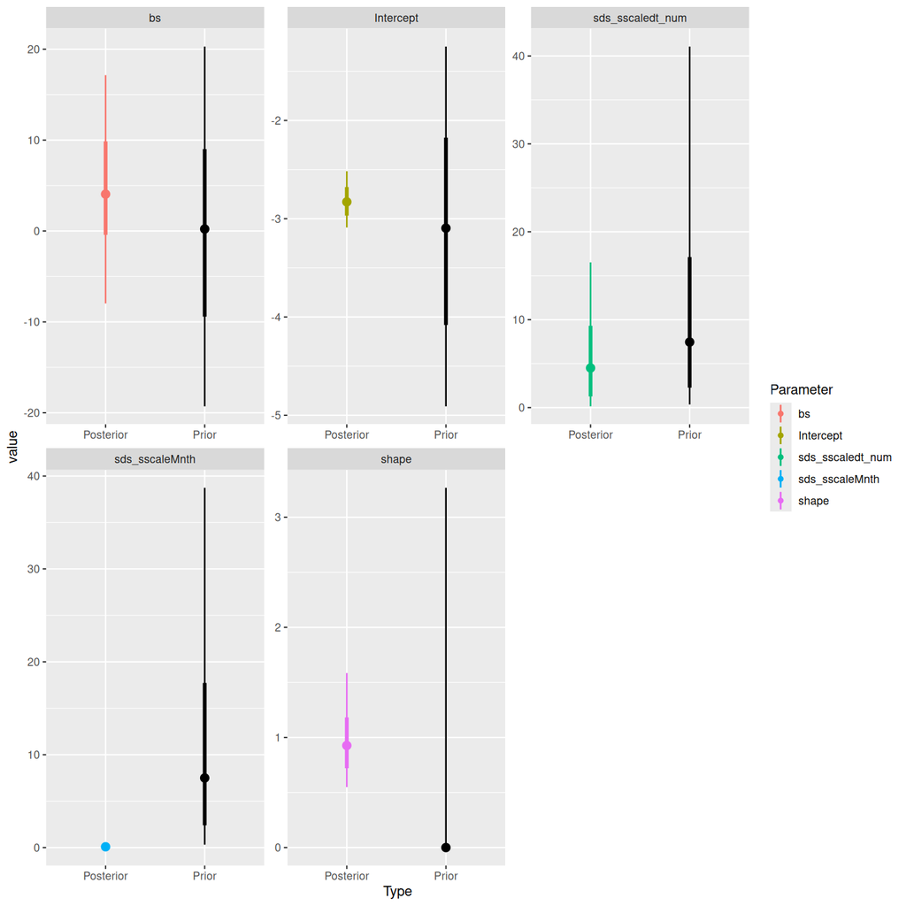

```r
wq_brm6a |> SUYR_prior_and_posterior()
```

**DHARMa residuals**

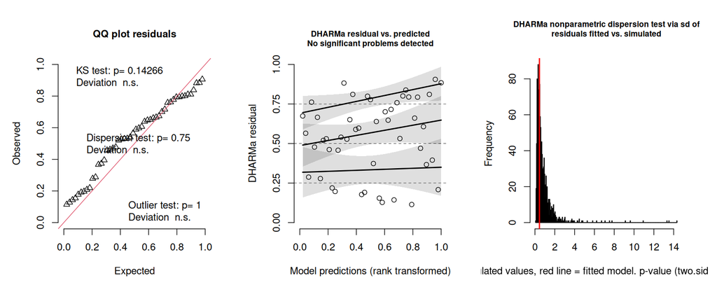

```r
wq.resids <- make_brms_dharma_res(wq_brm6a, integerResponse = FALSE)
wrap_elements(~testUniformity(wq.resids)) +
  ## wrap_elements(~plotResiduals(wq.resids, form = factor(rep(1, nrow(wq_sub))))) +
  wrap_elements(~plotResiduals(wq.resids, quantreg = TRUE)) +
  wrap_elements(~testDispersion(wq.resids))
```

```r
## testTemporalAutocorrelation(wq.resids, time =  wq_sub$dt_num)
## resids1 <- recalculateResiduals(wq.resids, group =  wq_sub$dt_num, aggregateBy =  mean)
## testTemporalAutocorrelation(resids1, time =  wq_sub$dt_num)
```

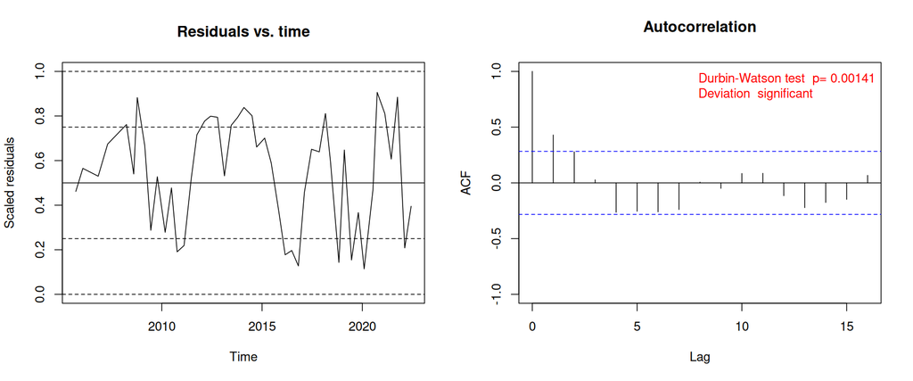

```
    Durbin-Watson test

data:  simulationOutput$scaledResiduals ~ 1
DW = 1.13, p-value = 0.001411
alternative hypothesis: true autocorrelation is not 0
```

```r
dt_num <- wq_brm6a$data$dt_num
## testTemporalAutocorrelation(wq.resids, time =  dt_num)
resids1 <- recalculateResiduals(wq.resids, group =  dt_num, aggregateBy =  mean)
testTemporalAutocorrelation(resids1, time =  dt_num)
```

**Find the peak**

```r
newdata <- with(wq_sub, data.frame(
  dt_num = seq(min(2010), max(2017), length = 1000),
  Mnth = 6
))
wq_peak <-
  add_epred_draws(
    object = wq_brm6a, newdata = newdata,
    re_formula = NA,
    ndraws = 1000
  ) |>
  ungroup() |>
  group_by(.draw) |>
  summarise(
    x = dt_num[which.max(.epred)],
    Nox = .epred[which.max(.epred)],
    .groups = "keep"
  ) |>
  ungroup() |>
  median_hdci(.width = 0.95) |>
  mutate(across(matches("^x"), lubridate::date_decimal)) |>
  mutate(across(matches("^x"), as.Date)) |>
  as.data.frame()
wq_peak
```

```
           x    x.lower    x.upper       Nox  Nox.lower Nox.upper .width .point
1 2013-12-04 2012-10-16 2017-01-01 0.0722781 0.03069286 0.1456725   0.95 median
  .interval
1      hdci
```

**Gaussian Process**

**Fit model**

```r
wq_sub <- wq_sub |>
    mutate(
      Mnth1 = cos(2 * pi * Mnth / 12),
      Mnth2 = sin(2 * pi * Mnth / 12)
    )
wq_form <- bf(NOx | cens(NOx_flag) ~ gp(dt_num) +
                gp(Mnth1, Mnth2),
  family = Gamma(link = "log"))
get_prior(wq_form, data = wq_sub)
```

```
                          prior     class         coef group resp dpar nlpar lb
        student_t(3, -3.1, 2.5) Intercept
                         (flat)    lscale                                     0
  inv_gamma(1.523334, 0.060727)    lscale     gpdt_num                        0
 inv_gamma(12.416145, 5.705771)    lscale gpMnth1Mnth2                        0
           student_t(3, 0, 2.5)      sdgp                                     0
           student_t(3, 0, 2.5)      sdgp     gpdt_num                        0
           student_t(3, 0, 2.5)      sdgp gpMnth1Mnth2                        0
              gamma(0.01, 0.01)     shape                                     0
 ub tag       source
             default
             default
             default
             default
             default
        (vectorized)
        (vectorized)
             default
```

```r
priors <- prior(normal(-3.1, 1), class = "Intercept") +
  prior(gamma(0.01, 0.01), class = "shape") +
  prior(inv_gamma(1.5, 0.06), class = "lscale", coef = "gpdt_num") +
  prior(inv_gamma(12.4, 5.7), class = "lscale", coef = "gpMnth1Mnth2") +
  prior(student_t(3, 0, 1), class = "sdgp")

wq_brm7a <- brm(wq_form,
  data = wq_sub,
  ## prior = priors,
  sample_prior = 'yes',
  iter = 3000,
  warmup = 1000,
  chains = 3, cores =  3,
  thin = 5,
  backend = "rstan",
  seed =  123,
  control =  list(adapt_delta =  0.99, max_treedepth = 20),
  refresh = 0)
```

[output not shown]

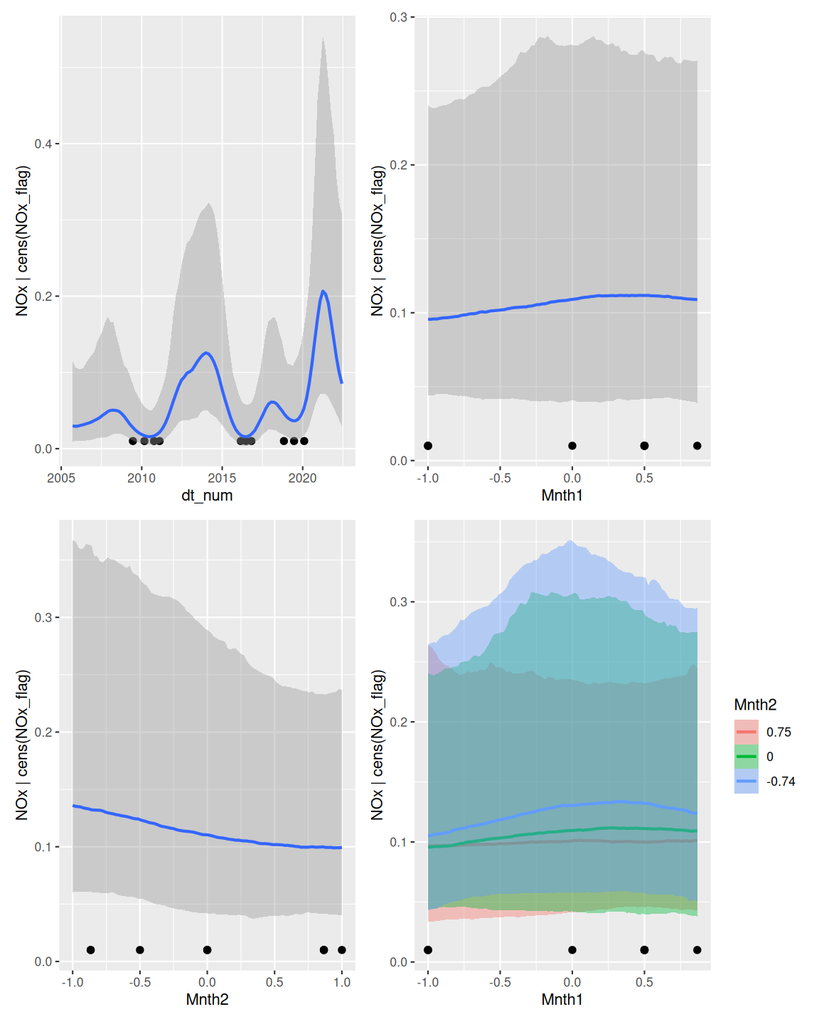

```r
wq_brm7a |>
    conditional_effects() |>
    plot(ask = FALSE, points = TRUE, plot = FALSE) |>
  wrap_plots()
```

```
Ignoring unknown labels:
• fill : "NA"
• colour : "NA"
Ignoring unknown labels:
• fill : "NA"
• colour : "NA"
```

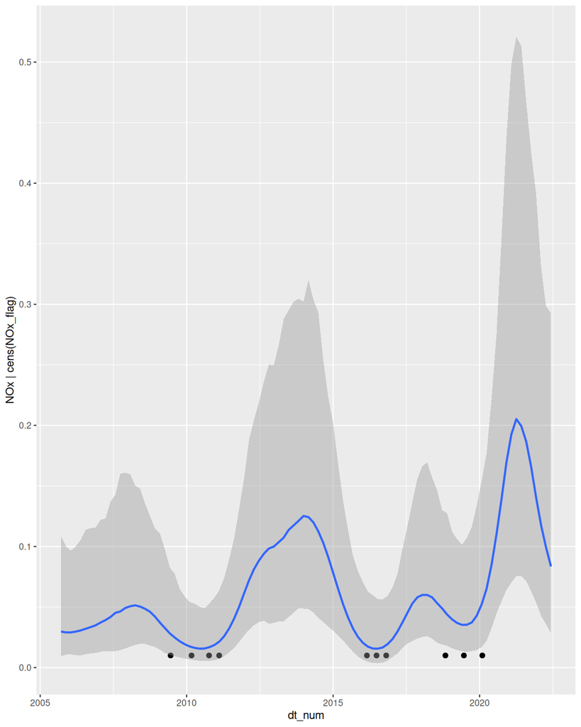

```
Ignoring unknown labels:
• fill : "NA"
```

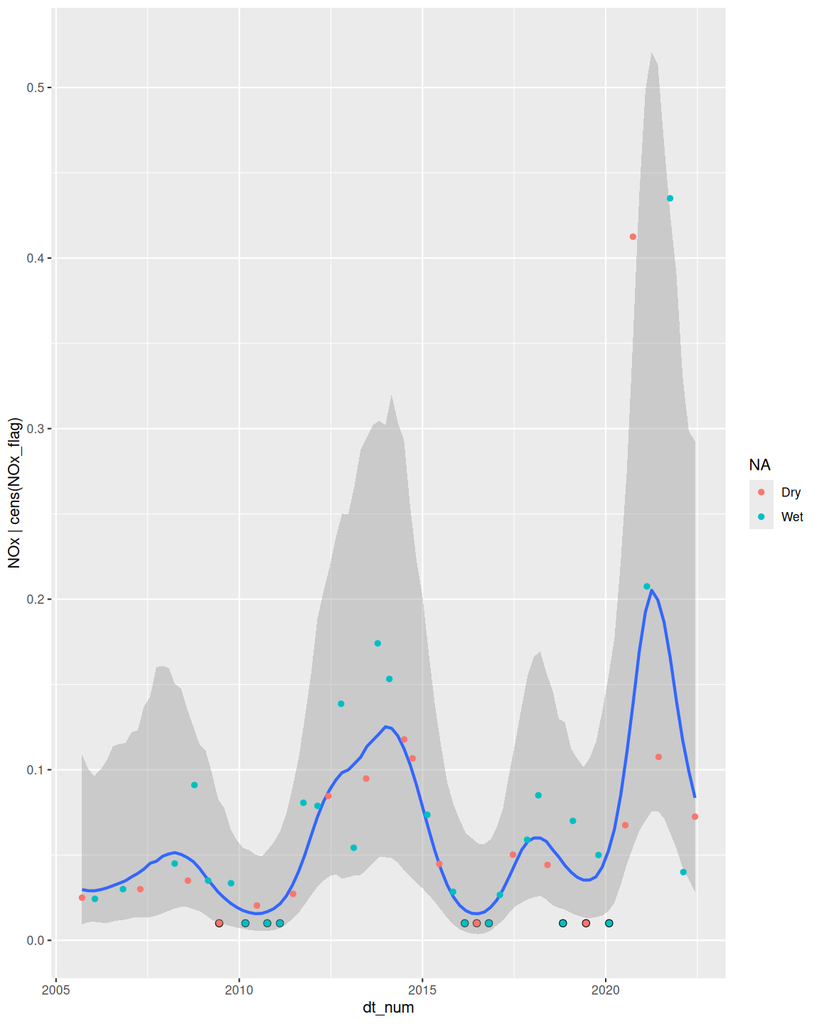

```r
wq_brm7a |> conditional_effects(effects = "dt_num") |>  plot(points=TRUE) |>
  _[[1]] +
  geom_point(data = wq_sub, inherit.aes = FALSE,
             aes(y = NOx, x = dt_num, colour = Season))
```

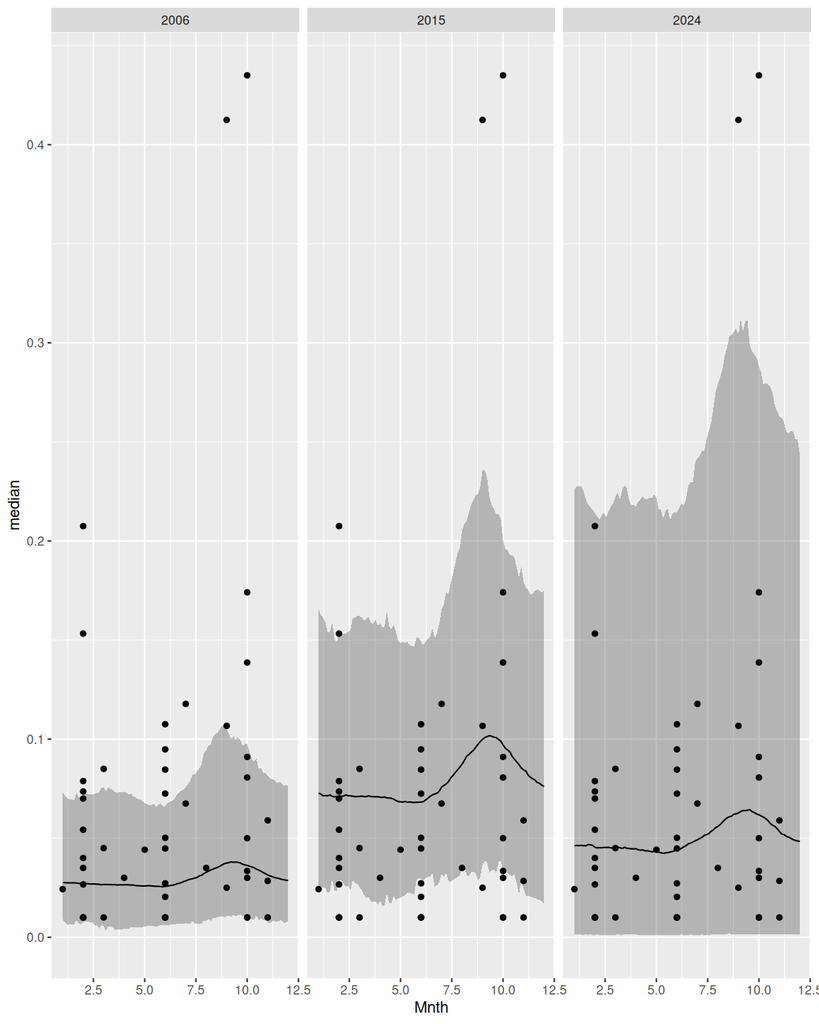

```r
newdata <- data.frame(Mnth = seq(1, 12, len = 100)) |>
    mutate(
        Mnth1 = cos(2 * pi * Mnth / 12),
        Mnth2 = sin(2 * pi * Mnth / 12)
    ) |>
  crossing(dt_num = c(2006, 2015, 2024))
# Expected response for every posterior draw
ep <- epred_draws(
  wq_brm7a,
  newdata = newdata,
  re_formula = NA
) |>
  ungroup() |>
  dplyr::select(Mnth, dt_num, .epred) |>
  group_by(Mnth, dt_num) |>
  summarise_draws(median, HDInterval::hdi)

ep |>
    ggplot(aes(y = median, x = Mnth)) +
    geom_ribbon(aes(ymin = lower, ymax = upper), alpha = 0.3) +
    geom_line() +
  annotate(geom = "point", x = wq_sub$Mnth, y = wq_sub$NOx) +
  facet_grid(~dt_num)
```

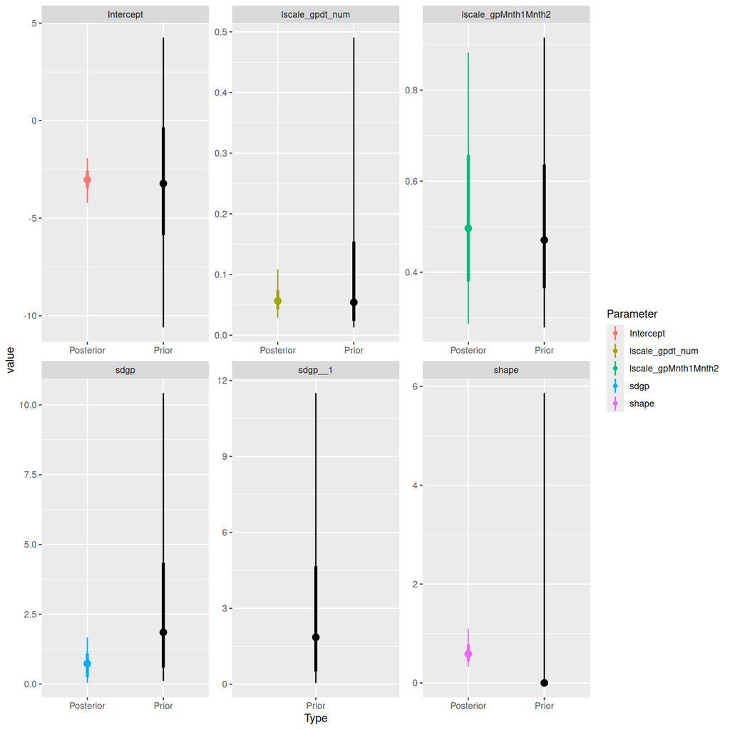

```r
wq_brm7a |> SUYR_prior_and_posterior()
```

**DHARMa residuals**

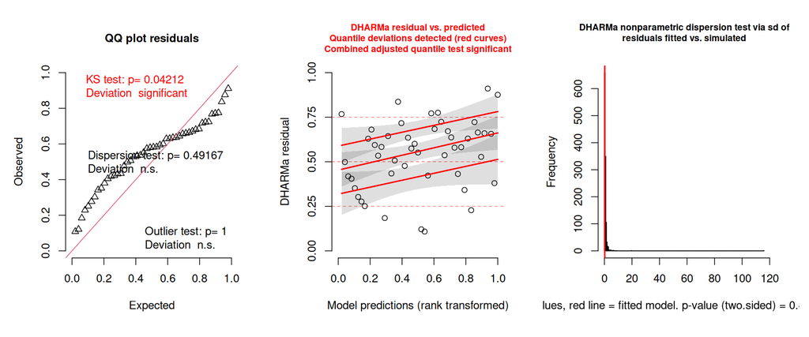

```r
wq.resids <- make_brms_dharma_res(wq_brm7a, integerResponse = FALSE)
wrap_elements(~testUniformity(wq.resids)) +
  ## wrap_elements(~plotResiduals(wq.resids, form = factor(rep(1, nrow(wq_sub))))) +
  wrap_elements(~plotResiduals(wq.resids, quantreg = TRUE)) +
  wrap_elements(~testDispersion(wq.resids))
```

```r
## testTemporalAutocorrelation(wq.resids, time =  wq_sub$dt_num)
## resids1 <- recalculateResiduals(wq.resids, group =  wq_sub$dt_num, aggregateBy =  mean)
## testTemporalAutocorrelation(resids1, time =  wq_sub$dt_num)
```

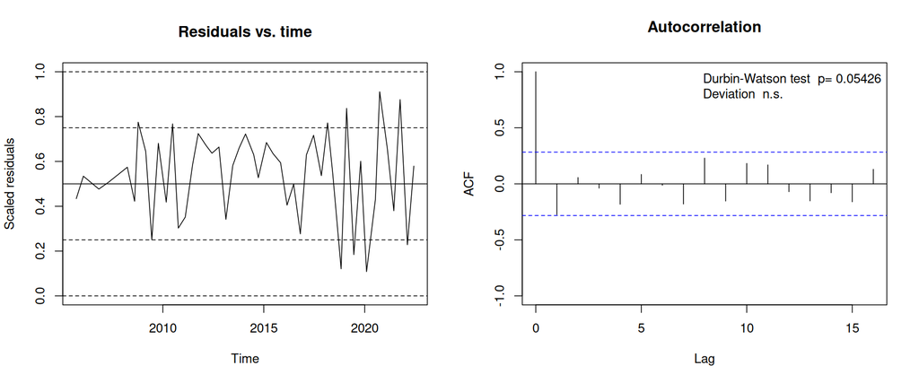

```
    Durbin-Watson test

data:  simulationOutput$scaledResiduals ~ 1
DW = 2.542, p-value = 0.05426
alternative hypothesis: true autocorrelation is not 0
```

```r
dt_num <- wq_brm7a$data$dt_num
## testTemporalAutocorrelation(wq.resids, time =  dt_num)
resids1 <- recalculateResiduals(wq.resids, group =  dt_num, aggregateBy =  mean)
testTemporalAutocorrelation(resids1, time =  dt_num)
```

**Find the peak**

```r
newdata <- with(wq_sub, data.frame(
  dt_num = seq(min(2010), max(2017), length = 1000),
  Mnth = 6
)) |>
  mutate(
    Mnth1 = cos(2 * pi * Mnth / 12),
    Mnth2 = sin(2 * pi * Mnth / 12)
  )
wq_peak <-
  add_epred_draws(
    object = wq_brm6a, newdata = newdata,
    re_formula = NA,
    ndraws = 1000
  ) |>
  ungroup() |>
  group_by(.draw) |>
  summarise(
    x = dt_num[which.max(.epred)],
    Nox = .epred[which.max(.epred)],
    .groups = "keep"
  ) |>
  ungroup() |>
  median_hdci(.width = 0.95) |>
  mutate(across(matches("^x"), lubridate::date_decimal)) |>
  mutate(across(matches("^x"), as.Date)) |>
  as.data.frame()
wq_peak
```

```
           x    x.lower    x.upper        Nox  Nox.lower Nox.upper .width
1 2013-11-18 2012-09-30 2017-01-01 0.07382676 0.03209298 0.1481808   0.95
  .point .interval
1 median      hdci
```

# 7 Mixed effects models (all reefs)

**Data preparation**

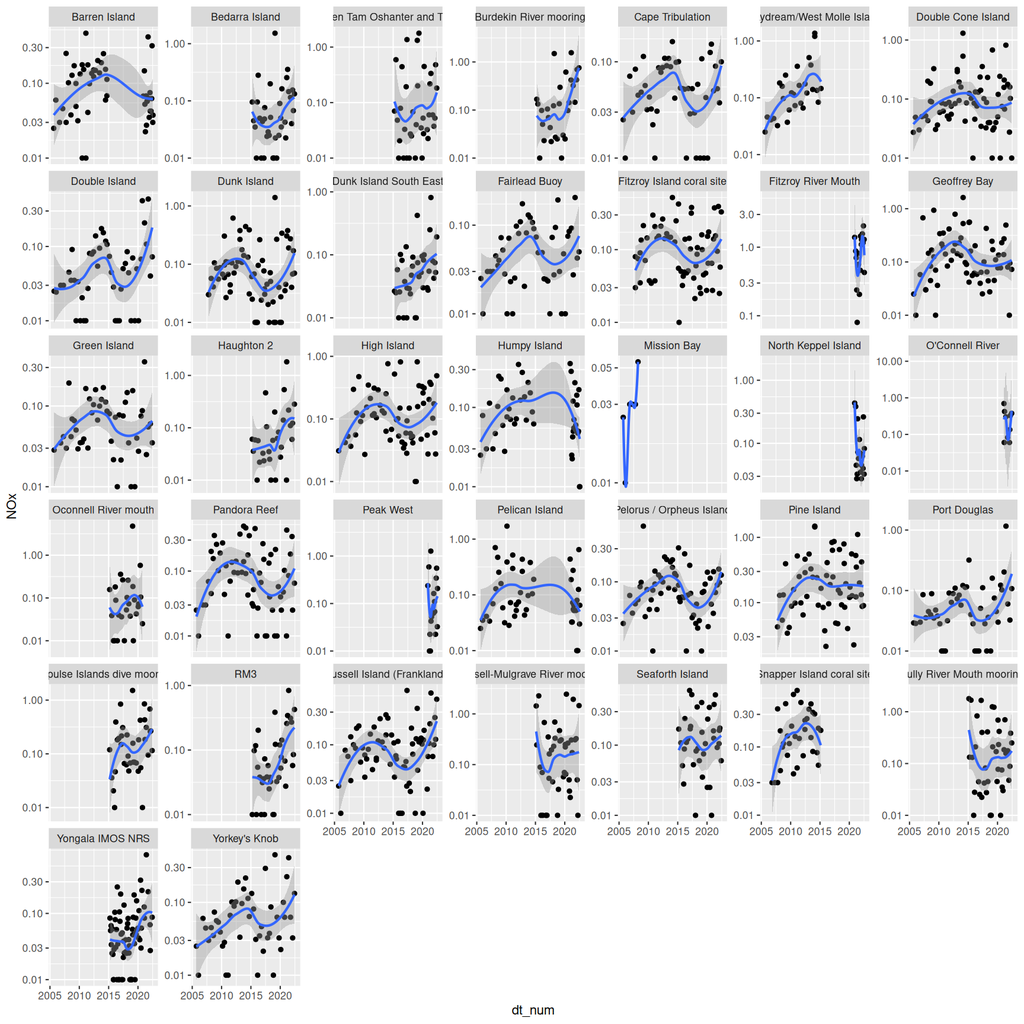

```r
ggplot(wq, aes(y=NOx,x=dt_num)) +
    geom_point() +
    facet_wrap(~Site, scales = 'free_y') +
    geom_smooth() +
    scale_y_log10()
```

```r
wq_sub2 <- wq |>
  group_by(Site) |>
  mutate(Min=min(dt_num)) |>
  ungroup() |>
  filter(Min<2012, Region != 'Fitzroy', reef.alias != 'Daydream') |>
  droplevels()
```

**EDA**

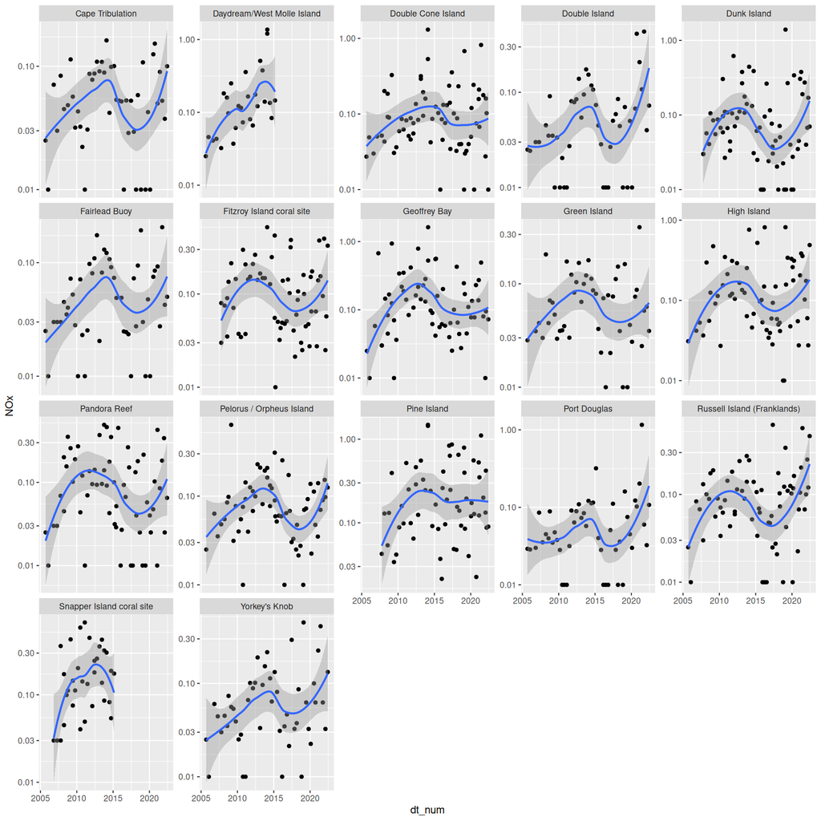

```r
ggplot(wq_sub2, aes(y=NOx,x=dt_num)) +
    geom_point() +
    facet_wrap(~Site, scales = 'free_y') +
    geom_smooth() +
    scale_y_log10()
```

**Date model**

**GAM**

**Fit model (priors only)**

```r
wq_form <- bf(NOx | cens(NOx_flag) ~ s(scale(dt_num)) + (1|reef.alias),
  family = Gamma(link = "log"))
get_prior(wq_form, data = wq_sub2)
```

```
                   prior     class             coef      group resp dpar nlpar
                  (flat)         b
                  (flat)         b   sscaledt_num_1
 student_t(3, -2.5, 2.5) Intercept
    student_t(3, 0, 2.5)        sd
    student_t(3, 0, 2.5)        sd                  reef.alias
    student_t(3, 0, 2.5)        sd        Intercept reef.alias
    student_t(3, 0, 2.5)       sds
    student_t(3, 0, 2.5)       sds s(scale(dt_num))
       gamma(0.01, 0.01)     shape
 lb ub tag       source
                default
           (vectorized)
                default
  0             default
  0        (vectorized)
  0        (vectorized)
  0             default
  0        (vectorized)
  0             default
```

```r
priors <- prior(normal(-3.1, 1),  class='Intercept') +
  prior(normal(0, 10), class='b') +
  prior(gamma(0.01, 0.01),  class='shape') +
  prior(student_t(3, 0, 10), class =  "sds") +
  prior(student_t(3, 0, 1), class =  "sd")

wq_brm8 <- brm(wq_form,
                 data = wq_sub2,
                 prior = priors,
                 sample_prior = 'only',
                 iter = 5000,
                 warmup = 1000,
                 chains = 3, cores =  3,
                 thin = 5,
                 backend = "rstan",
                 seed =  123,
                 control =  list(adapt_delta =  0.99, max_treedepth = 20),
                 refresh = 0)
```

```
Ignoring unknown labels:
• fill : "NA"
• colour : "NA"
Ignoring unknown labels:
• fill : "NA"
• colour : "NA"
```

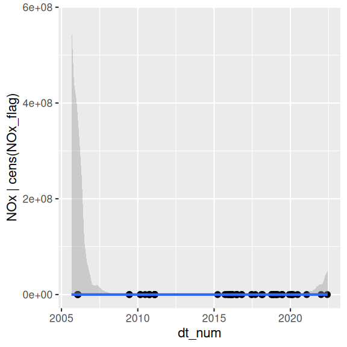

```r
wq_brm8 |> conditional_effects(effects = "dt_num") |>  plot(points=TRUE)
```

```
Ignoring unknown labels:
• fill : "NA"
• colour : "NA"
Ignoring unknown labels:
• fill : "NA"
• colour : "NA"
```

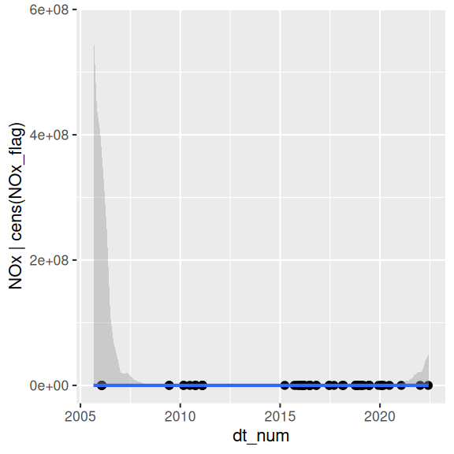

```
Ignoring unknown labels:
• fill : "NA"
• colour : "NA"
```

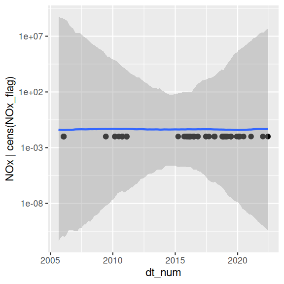

```r
wq_brm8 |> conditional_effects(effects = "dt_num") |>  plot(points=TRUE) |>
  _[[1]] +
  scale_y_log10()
```

**Sample prior and posterior**

```r
wq_brm9 <- update(wq_brm8, sample_prior = "yes", cores =  3, seed = 123, refresh =  0)
```

```
The desired updates require recompiling the model
```

**Conditional effects plot**

```
Ignoring unknown labels:
• fill : "NA"
• colour : "NA"
Ignoring unknown labels:
• fill : "NA"
• colour : "NA"
```

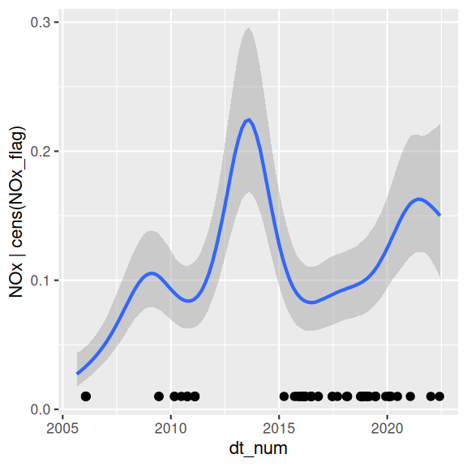

```r
wq_brm9 |> conditional_effects(effects = "dt_num") |>  plot(points=TRUE)
```

```
Ignoring unknown labels:
• fill : "NA"
• colour : "NA"
Ignoring unknown labels:
• fill : "NA"
• colour : "NA"
```

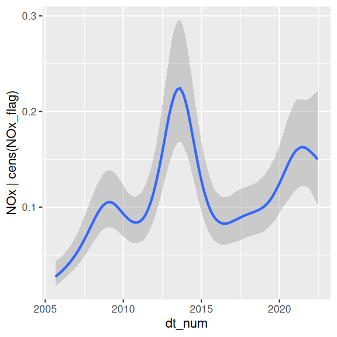

```r
wq_brm9 |> conditional_effects(effects = "dt_num")
```

```
Ignoring unknown labels:
• fill : "NA"
• colour : "NA"
Ignoring unknown labels:
• fill : "NA"
• colour : "NA"
```

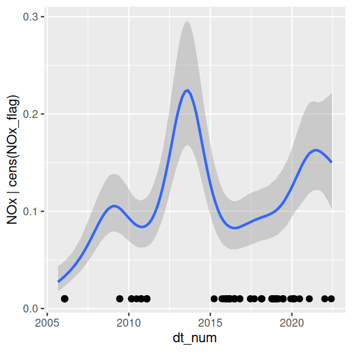

```
Ignoring unknown labels:
• fill : "NA"
• colour : "NA"
```

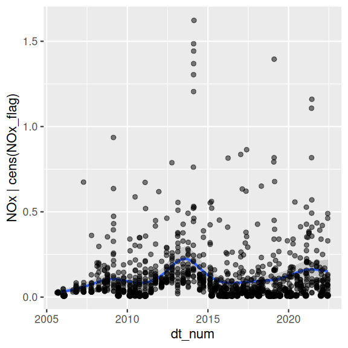

```r
wq_brm9 |>
    conditional_effects(effects = "dt_num") |>
    plot(points = TRUE) |>
  _[[1]] +
  geom_point(data = wq_sub2, inherit.aes = FALSE,
             aes(y = NOx, x = dt_num), alpha = 0.5)
```

**Plotting prior and posterior**

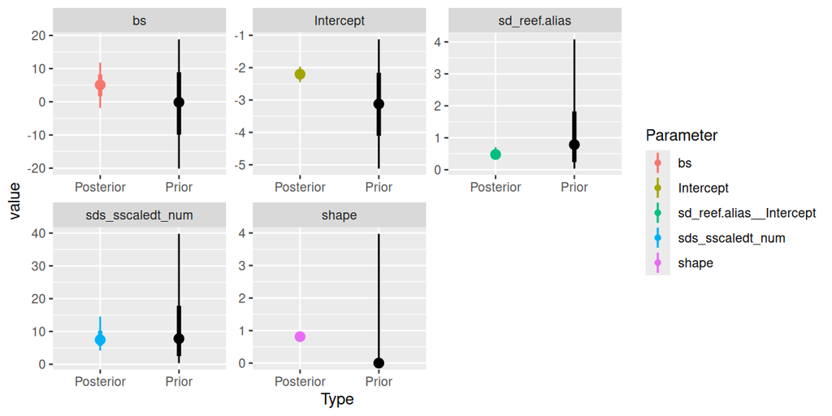

```r
wq_brm9 |> SUYR_prior_and_posterior()
```

**DHARMa residuals**

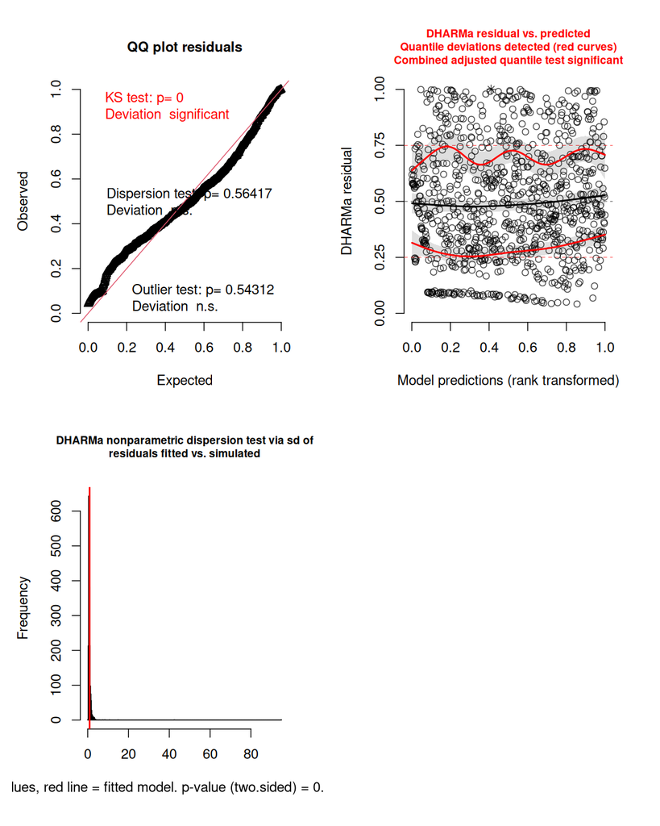

```r
wq_resids <- make_brms_dharma_res(wq_brm9, integerResponse = FALSE)
wrap_elements(~testUniformity(wq_resids)) +
  wrap_elements(~plotResiduals(wq_resids, quantreg = TRUE)) +
  wrap_elements(~testDispersion(wq_resids)) +
  plot_layout(nrow =  2)
```

**Find the peak**

```r
newdata <- with(wq_sub2, data.frame(
  dt_num = seq(min(2010), max(2017), length = 1000)
))
wq_peak <-
  add_epred_draws(
    object = wq_brm9, newdata = newdata,
    re_formula = NA,
    ndraws = 1000
  ) |>
  ungroup() |>
  group_by(.draw) |>
  summarise(
    x = dt_num[which.max(.epred)],
    Nox = .epred[which.max(.epred)],
    .groups = "keep"
  ) |>
  ungroup() |>
  median_hdci(.width = 0.95) |>
  mutate(across(matches("^x"), lubridate::date_decimal)) |>
  mutate(across(matches("^x"), as.Date)) |>
  as.data.frame()
wq_peak
```

```
           x    x.lower    x.upper      Nox Nox.lower Nox.upper .width .point
1 2013-07-29 2013-05-21 2013-10-08 0.226728 0.1620973 0.2930476   0.95 median
  .interval
1      hdci
```

**Gaussian Process**

**Fit model**

**Warning** if exact GPs are to be computed, this models will take a long time. A faster version can be obtained by computing Hilbert-space approximate GPs by indicating the number of basis functions to be (e.g.) 20.

```r
wq_form <- bf(NOx | cens(NOx_flag) ~ gp(dt_num, k = 20, c = 5/4) + (1 | reef.alias),
  family = Gamma(link = "log")
)
wq_sub2 |> summarise(
    median(log(NOx), na.rm = TRUE), mad(log(NOx), na.rm = TRUE),
    mad(log(NOx)) / mad(scale(dt_num))
)
```

```
# A tibble: 1 × 3
  `median(log(NOx), na.rm = TRUE)` mad(log(NOx), na.rm …¹ mad(log(NOx))/mad(sc…²
                             <dbl>                  <dbl>                  <dbl>
1                            -2.53                   1.02                     NA
# ℹ abbreviated names: ¹`mad(log(NOx), na.rm = TRUE)`,
#   ²`mad(log(NOx))/mad(scale(dt_num))`
```

```r
get_prior(wq_form, data = wq_sub2)
```

```
Warning: Rows containing NAs were excluded from the model.
```

```
                         prior     class      coef      group resp dpar nlpar
       student_t(3, -2.5, 2.5) Intercept
                        (flat)    lscale
 inv_gamma(1.494197, 0.056607)    lscale  gpdt_num
          student_t(3, 0, 2.5)        sd
          student_t(3, 0, 2.5)        sd           reef.alias
          student_t(3, 0, 2.5)        sd Intercept reef.alias
          student_t(3, 0, 2.5)      sdgp
          student_t(3, 0, 2.5)      sdgp  gpdt_num
             gamma(0.01, 0.01)     shape
 lb ub tag       source
                default
  0             default
  0             default
  0             default
  0        (vectorized)
  0        (vectorized)
  0             default
  0        (vectorized)
  0             default
```

```r
priors <- prior(normal(-3.1, 1), class = "Intercept") +
  prior(gamma(0.01, 0.01), class = "shape") +
  prior(inv_gamma(4.6, 0.4), class = "lscale", coef = "gpdt_num") +
  prior(student_t(3, 0, 1), class =  "sdgp")

wq_brm10a <- brm(wq_form,
                 data = wq_sub2,
                 prior = priors,
                 sample_prior = 'yes',
                 iter = 3000,
                 warmup = 1000,
                 thin = 5,
                 chains = 3, cores =  3,
                 backend = "rstan",
                 seed =  123,
                 control =  list(adapt_delta = 0.99, max_treedepth = 20),
                 refresh = 0)
```

**Conditional effects plot**

```
Ignoring unknown labels:
• fill : "NA"
• colour : "NA"
Ignoring unknown labels:
• fill : "NA"
• colour : "NA"
```

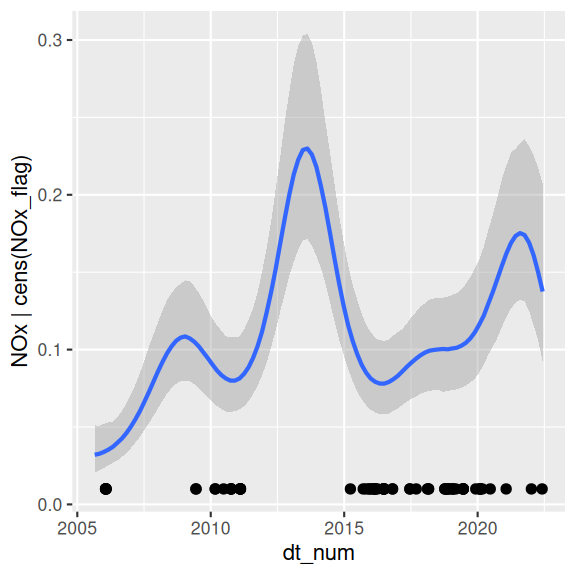

```r
wq_brm10a |> conditional_effects(effects = "dt_num") |>  plot(points=TRUE)
```

```
Ignoring unknown labels:
• fill : "NA"
• colour : "NA"
Ignoring unknown labels:
• fill : "NA"
• colour : "NA"
```

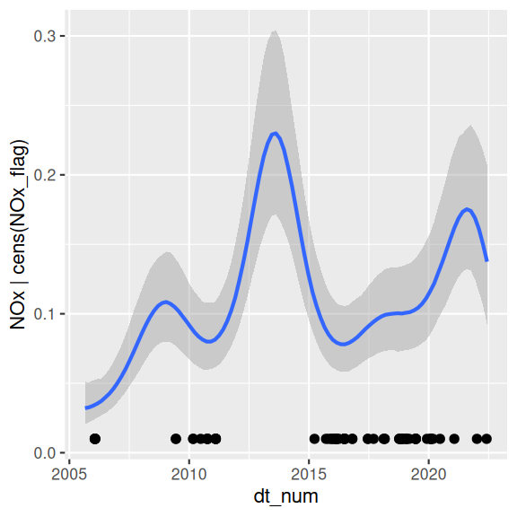

```
Ignoring unknown labels:
• fill : "NA"
• colour : "NA"
```

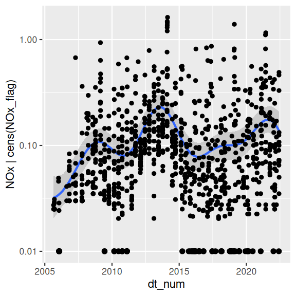

```r
wq_brm10a |>
    conditional_effects(effects = "dt_num") |>
    plot(points = TRUE) |>
    _[[1]] +
  scale_y_log10() +
  geom_point(
    data = wq_sub2, inherit.aes = FALSE,
    aes(y = NOx, x = dt_num)
  )
```

**Find the peak**

```r
newdata <- with(wq_sub2, data.frame(
  dt_num = seq(min(2010), max(2017), length = 1000)
))
wq_peak <-
  add_epred_draws(
    object = wq_brm10a, newdata = newdata,
    re_formula = NA,
    ndraws = 1000
  ) |>
  ungroup() |>
  group_by(.draw) |>
  summarise(
    x = dt_num[which.max(.epred)],
    Nox = .epred[which.max(.epred)],
    .groups = "keep"
  ) |>
  ungroup() |>
  median_hdci(.width = 0.95) |>
  mutate(across(matches("^x"), lubridate::date_decimal)) |>
  mutate(across(matches("^x"), as.Date)) |>
  as.data.frame()
wq_peak
```

```
           x    x.lower    x.upper       Nox Nox.lower Nox.upper .width .point
1 2013-07-26 2013-05-13 2013-10-06 0.2295364 0.1708099 0.3029154   0.95 median
  .interval
1      hdci
```

**Date and month model**

**GAM**

**Fit model (priors only)**

```r
wq_form <- bf(NOx | cens(NOx_flag) ~ s(scale(dt_num)) +
                s(scale(Mnth), bs = "cc") +
                (1|reef.alias),
  family = Gamma(link = "log"))
get_prior(wq_form, data = wq_sub2)
```

```
                   prior     class                      coef      group resp
                  (flat)         b
                  (flat)         b            sscaledt_num_1
 student_t(3, -2.5, 2.5) Intercept
    student_t(3, 0, 2.5)        sd
    student_t(3, 0, 2.5)        sd                           reef.alias
    student_t(3, 0, 2.5)        sd                 Intercept reef.alias
    student_t(3, 0, 2.5)       sds
    student_t(3, 0, 2.5)       sds          s(scale(dt_num))
    student_t(3, 0, 2.5)       sds s(scale(Mnth), bs = "cc")
       gamma(0.01, 0.01)     shape
 dpar nlpar lb ub tag       source
                           default
                      (vectorized)
                           default
             0             default
             0        (vectorized)
             0        (vectorized)
             0             default
             0        (vectorized)
             0        (vectorized)
             0             default
```

```r
priors <- prior(normal(-3.1, 1),  class='Intercept') +
  prior(normal(0, 10), class='b') +
  prior(gamma(0.01, 0.01),  class='shape') +
  prior(student_t(3, 0, 10), class =  "sds") +
  prior(student_t(3, 0, 1), class =  "sd")

wq_brm11a <- brm(wq_form,
                 data = wq_sub2,
                 prior = priors,
                 sample_prior = 'only',
                 iter = 5000,
                 warmup = 1000,
                 chains = 3, cores =  3,
                 thin = 5,
                 backend = "rstan",
                 seed =  123,
                 control =  list(adapt_delta =  0.99, max_treedepth = 20),
                 refresh = 0)
```

```
Ignoring unknown labels:
• fill : "NA"
• colour : "NA"
Ignoring unknown labels:
• fill : "NA"
• colour : "NA"
```

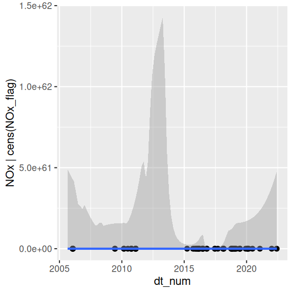

```
Ignoring unknown labels:
• fill : "NA"
• colour : "NA"
```

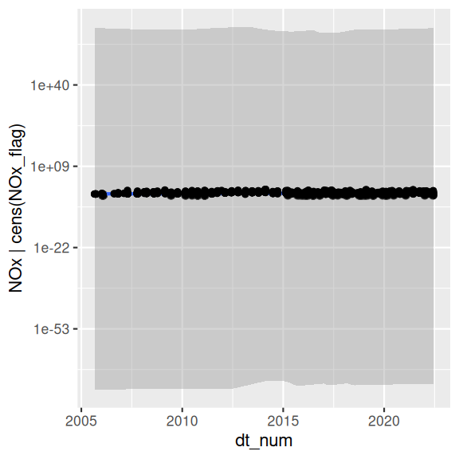

```r
wq_brm11a |>
    conditional_effects(effects = "dt_num") |>
    plot(points = TRUE) |>
    _[[1]] +
    scale_y_log10() +
    geom_point(
        data = wq_sub2, inherit.aes = FALSE,
        aes(y = NOx, x = dt_num)
    )
```

**Sample prior and posterior**

```r
wq_brm11b <- update(wq_brm11a, sample_prior = "yes", cores =  3, seed = 123, refresh =  0)
```

```
The desired updates require recompiling the model
```

**Conditional effects plot**

```
Ignoring unknown labels:
• fill : "NA"
• colour : "NA"
Ignoring unknown labels:
• fill : "NA"
• colour : "NA"
```

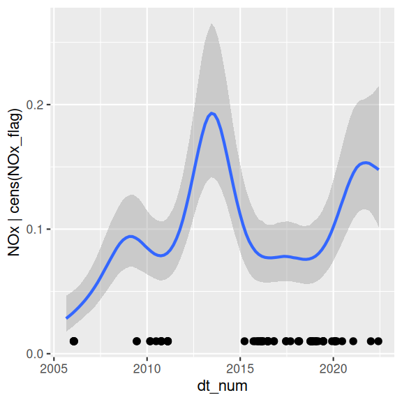

```r
wq_brm11b |> conditional_effects(effects = "dt_num") |>  plot(points=TRUE)
```

```
Ignoring unknown labels:
• fill : "NA"
• colour : "NA"
Ignoring unknown labels:
• fill : "NA"
• colour : "NA"
```

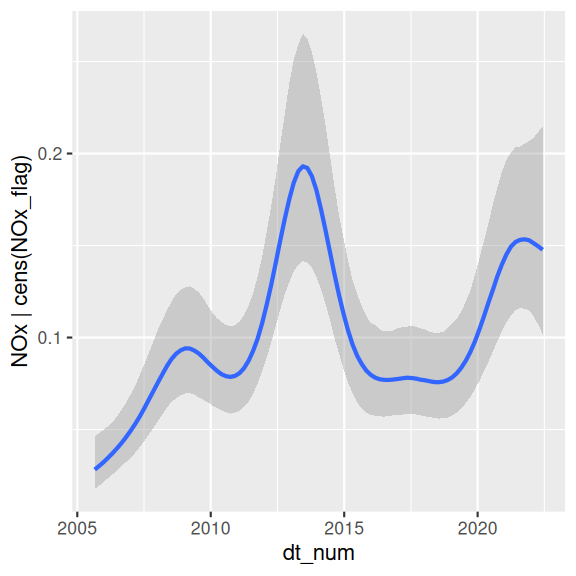

```r
wq_brm11b |> conditional_effects(effects = "dt_num")
```

```
Ignoring unknown labels:
• fill : "NA"
• colour : "NA"
Ignoring unknown labels:
• fill : "NA"
• colour : "NA"
```

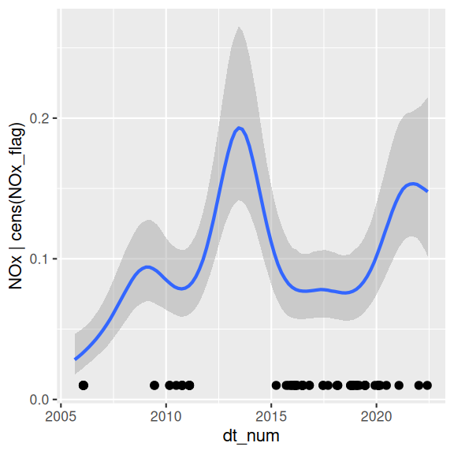

```
Ignoring unknown labels:
• fill : "NA"
• colour : "NA"
```

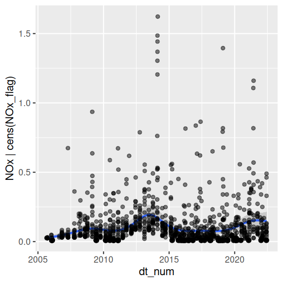

```r
wq_brm11b |>
    conditional_effects(effects = "dt_num") |>
    plot(points = TRUE) |>
  _[[1]] +
  geom_point(data = wq_sub2, inherit.aes = FALSE,
             aes(y = NOx, x = dt_num), alpha = 0.5)
```